# CLIP V3 Forensic Experiment Audit

### Variance Decomposition

This section estimates how much of the observed validation macro-F1 variation appears to be associated with recipe identity, seed, and fold. The goal is not to create a new ranking rule, but to judge whether late-stage gaps are large relative to the experiment's own noise scale.

**Global variance decomposition across all CV runs**

|  | factor | approx_variance_share |
| --- | --- | --- |
| 0 | recipe | 0.457406 |
| 1 | seed | 0.000908 |
| 2 | fold | 0.320746 |
| 3 | full_model_explained | 0.780808 |

**Late-stage variance decomposition**

|  | factor | approx_variance_share |
| --- | --- | --- |
| 0 | recipe | 0.022398 |
| 1 | seed | 0.005816 |
| 2 | fold | 0.700027 |
| 3 | full_model_explained | 0.725728 |

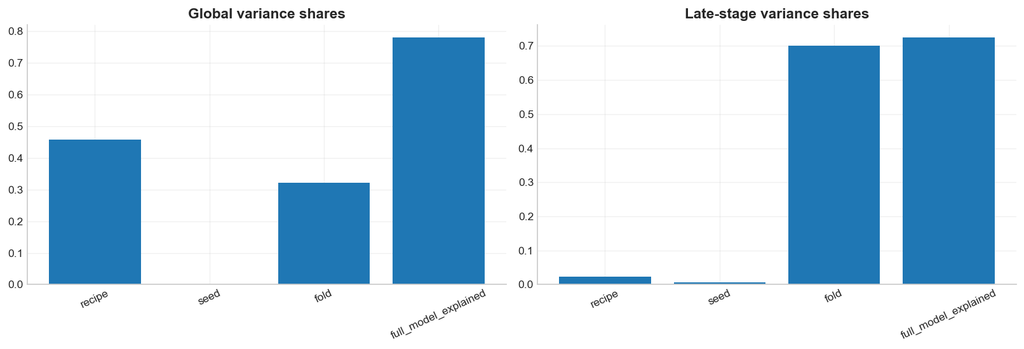

**Graph note**

These bars show how much observed validation variation is associated with recipe identity, seed, and fold in the additive approximation used by the notebook.

How to read it: Larger shares mean that factor explains more of the observed macro-F1 movement. Comparing the full-search panel with the late-stage panel helps judge whether late recipe gaps are large relative to the experiment's noise scale.

These are heuristic variance shares, not formal variance-components estimates.

```
    **Finding.** Across the full search, recipe identity explains the largest share of observed macro-F1 variation
    when compared with seed and fold effects in this additive approximation. The exact percentages should not be over-read as causal,
    but they do provide a useful scale check: later-stage margins that are materially smaller than the seed/fold noise floor should be described cautiously,
    while larger stage shifts are more plausibly recipe-driven.
```

```python
variance_global_df = variance_decomposition(cv_results.copy())
display(Markdown("**Global variance decomposition across all CV runs**"))
display(variance_global_df)

late_subset = cv_results[cv_results["stage"].isin(["s8_aux", "s9_bb2", "s10_opt", "s11_rob"])].copy()
variance_late_df = variance_decomposition(late_subset)
display(Markdown("**Late-stage variance decomposition**"))
display(variance_late_df)

fig, axes = plt.subplots(1, 2, figsize=(13, 4.5))
axes[0].bar(variance_global_df["factor"], variance_global_df["approx_variance_share"])
axes[0].set_title("Global variance shares")
axes[0].tick_params(axis="x", rotation=25)
axes[1].bar(variance_late_df["factor"], variance_late_df["approx_variance_share"])
axes[1].set_title("Late-stage variance shares")
axes[1].tick_params(axis="x", rotation=25)
fig.tight_layout()
plt.show()
plt.close(fig)
display_note(
    title="Graph note",
    purpose="These bars show how much observed validation variation is associated with recipe identity, seed, and fold in the additive approximation used by the notebook.",
    how_to_read="Larger shares mean that factor explains more of the observed macro-F1 movement. Comparing the full-search panel with the late-stage panel helps judge whether late recipe gaps are large relative to the experiment's noise scale.",
    caveat="These are heuristic variance shares, not formal variance-components estimates."
)

recipe_share = float(variance_global_df.loc[variance_global_df["factor"] == "recipe", "approx_variance_share"].iloc[0])
seed_share = float(variance_global_df.loc[variance_global_df["factor"] == "seed", "approx_variance_share"].iloc[0])
fold_share = float(variance_global_df.loc[variance_global_df["factor"] == "fold", "approx_variance_share"].iloc[0])
display(
    Markdown(
        f'''
        **Finding.** Across the full search, recipe identity explains the largest share of observed macro-F1 variation
        when compared with seed and fold effects in this additive approximation. The exact percentages should not be over-read as causal,
        but they do provide a useful scale check: later-stage margins that are materially smaller than the seed/fold noise floor should be described cautiously,
        while larger stage shifts are more plausibly recipe-driven.
        '''
    )
)
```

### Ranking-Stability Stress Tests

These checks stress-test the existing stage conclusions without inventing a new selection rule. The question is whether the saved winners remain convincing once the winner-vs-runner gap is viewed fold-by-fold and seed-by-seed.

|  | stage | winner_margin | paired_delta_mean | paired_delta_sd | sign_consistency | ci_low | ci_high | confidence |
| --- | --- | --- | --- | --- | --- | --- | --- | --- |
| 0 | s1_arch | 0.001495 | 0.001495 | 0.009407 | 0.600000 | -0.003309 | 0.005902 | weak |
| 1 | s2_om | 0.003104 | 0.003104 | 0.006947 | 0.666667 | -0.000075 | 0.006816 | moderate |
| 2 | s3_ls | 0.003104 | 0.003104 | 0.006947 | 0.666667 | -0.000086 | 0.006767 | moderate |
| 3 | s4_cw | 0.002805 | 0.002805 | 0.009310 | 0.666667 | -0.001509 | 0.007487 | moderate |
| 4 | s5_sp | 0.002805 | 0.002805 | 0.009310 | 0.666667 | -0.001684 | 0.007382 | moderate |
| 5 | s6_bt | 0.002805 | 0.002805 | 0.009310 | 0.666667 | -0.001692 | 0.007446 | moderate |
| 6 | s7_pd | 0.002763 | 0.002763 | 0.009856 | 0.600000 | -0.002080 | 0.007388 | weak |
| 7 | s8_aux | 0.001846 | 0.001846 | 0.004865 | 0.666667 | -0.000707 | 0.004164 | moderate |
| 8 | s9_bb2 | 0.001846 | 0.001846 | 0.004865 | 0.666667 | -0.000783 | 0.004154 | moderate |
| 9 | s10_opt | 0.000225 | 0.000225 | 0.000872 | 0.066667 | 0.000000 | 0.000675 | weak |
| 10 | s11_rob | 0.000112 | 0.000112 | 0.000690 | 0.040000 | -0.000069 | 0.000405 | weak |

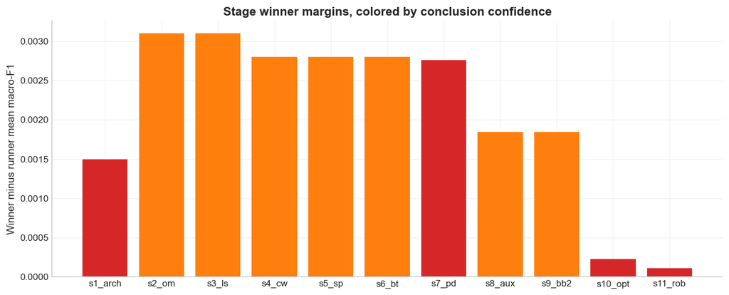

**Graph note**

This chart visualizes how convincing each stage winner looks once the winner margin is compared to paired fold/seed evidence.

How to read it: Taller bars mean a larger winner-minus-runner macro-F1 gap. The colors summarize the notebook's heuristic confidence labels, so weak or moderate colors on small bars should be read as tentative stage conclusions.

The colors are summaries of the notebook evidence, not significance tests.

```
    **Finding.** Several stage conclusions are clearly more stable than others. Weak stages should be treated as tentative or pseudo-separated when their
    margins sit near the observed paired-delta noise scale. The robustness rerun did not change the exact top signature
    relative to Stage 10, which is a direct check on whether the light-budget optimizer result held up under a broader seed budget. The most caution-worthy stages are:
    `s1_arch, s7_pd, s10_opt, s11_rob`. Moderate-but-not-airtight stages are:
    `s2_om, s3_ls, s4_cw, s5_sp, s6_bt, s8_aux, s9_bb2`.
```

```python
stability_rows = []
for stage_name in stage_order:
    df = stage_df(stage_name)
    if len(df) < 2:
        continue
    winner = df.iloc[0]
    runner = df.iloc[1]
    deltas = paired_stage_deltas(stage_name, winner["spec_signature"], runner["spec_signature"])
    ci = bootstrap_mean_ci(deltas)
    stability_rows.append(
        {
            "stage": stage_name,
            "winner_margin": float(winner["val_macro_f1_mean"] - runner["val_macro_f1_mean"]),
            "paired_delta_mean": float(np.mean(deltas)) if len(deltas) else np.nan,
            "paired_delta_sd": float(np.std(deltas, ddof=1)) if len(deltas) > 1 else np.nan,
            "sign_consistency": float((deltas > 0).mean()) if len(deltas) else np.nan,
            "ci_low": ci[0] if ci is not None else np.nan,
            "ci_high": ci[1] if ci is not None else np.nan,
            "confidence": stability_label(float(winner["val_macro_f1_mean"] - runner["val_macro_f1_mean"]), deltas),
        }
    )
stability_df = pd.DataFrame(stability_rows)
display(stability_df)

fig, ax = plt.subplots(figsize=(11, 4.5))
ax.bar(stability_df["stage"], stability_df["winner_margin"], color=["tab:green" if c == "strong" else "tab:orange" if c == "moderate" else "tab:red" for c in stability_df["confidence"]])
ax.set_ylabel("Winner minus runner mean macro-F1")
ax.set_title("Stage winner margins, colored by conclusion confidence")
fig.tight_layout()
plt.show()
plt.close(fig)
display_note(
    title="Graph note",
    purpose="This chart visualizes how convincing each stage winner looks once the winner margin is compared to paired fold/seed evidence.",
    how_to_read="Taller bars mean a larger winner-minus-runner macro-F1 gap. The colors summarize the notebook's heuristic confidence labels, so weak or moderate colors on small bars should be read as tentative stage conclusions.",
    caveat="The colors are summaries of the notebook evidence, not significance tests."
)

robust_family_changed = stage_df("s10_opt").iloc[0]["spec_signature"] != stage_df("s11_rob").iloc[0]["spec_signature"]
weak_stages = stability_df.loc[stability_df["confidence"] == "weak", "stage"].tolist()
moderate_stages = stability_df.loc[stability_df["confidence"] == "moderate", "stage"].tolist()

display(
    Markdown(
        f'''
        **Finding.** Several stage conclusions are clearly more stable than others. Weak stages should be treated as tentative or pseudo-separated when their
        margins sit near the observed paired-delta noise scale. The robustness rerun {'did' if robust_family_changed else 'did not'} change the exact top signature
        relative to Stage 10, which is a direct check on whether the light-budget optimizer result held up under a broader seed budget. The most caution-worthy stages are:
        `{', '.join(weak_stages) if weak_stages else 'none'}`. Moderate-but-not-airtight stages are:
        `{', '.join(moderate_stages) if moderate_stages else 'none'}`.
        '''
    )
)
```

## Final Model Audit

The beam search above explains how the shortlist was formed. The remaining sections audit what those shortlisted models actually do after selection. The order is intentional: the notebook first checks whether the finalists themselves are steady, then how the late training curves behave, then whether the ensemble and calibration help, and only after that moves into modality, head-consistency, error, and interpretability questions.

```python
extra_audit_inventory_rows = []
extra_audit_expected = [
    ("summary_tables/model_summary.csv", "finalist metrics"),
    ("summary_tables/prediction_audit.csv", "per-example finalist + ensemble audit"),
    ("summary_tables/pairwise_disagreement.csv", "redundancy / overlap table"),
    ("summary_tables/leave_one_out_ensemble.csv", "leave-one-out ensemble table"),
    ("summary_tables/modality_ablation_summary.csv", "modality reliance summary"),
    ("summary_tables/modality_ablation_by_class.csv", "class-level modality deltas"),
    ("summary_tables/head_consistency_summary.csv", "internal head-consistency summary"),
    ("summary_tables/head_consistency_alert_cases.csv", "head-disagreement alert cases"),
    ("summary_tables/interpretability_queries.csv", "selected query cases"),
    ("summary_tables/knn_casebook.csv", "nearest-neighbor casebook table"),
    ("summary_tables/ensemble_fix_harm_cases.csv", "ensemble fix / harm cases"),
    ("summary_tables/representation_structure_summary.csv", "all-finalist representation summary"),
    ("plots/coverage_vs_risk.png", "coverage-risk plot"),
    ("plots/modality_reliance.png", "modality reliance plot"),
    ("plots/head_disagreement_vs_error.png", "head-consistency plot"),
    ("casebooks/knn_casebook.html", "nearest-neighbor HTML casebook"),
    ("report.md", "extra audit markdown report"),
]
for rel_path, description in extra_audit_expected:
    path = EXTRA_AUDIT_ROOT / rel_path
    extra_audit_inventory_rows.append(
        {
            "artifact": rel_path,
            "description": description,
            "exists": bool(path.exists()),
        }
    )
extra_audit_inventory_df = pd.DataFrame(extra_audit_inventory_rows)
display(extra_audit_inventory_df)

if not extra_audit_inventory_df["exists"].all():
    missing = extra_audit_inventory_df.loc[~extra_audit_inventory_df["exists"], "artifact"].tolist()
    raise FileNotFoundError(f"Missing extra audit artifacts: {missing}")

audit_model_summary_df = load_extra_audit_csv("model_summary.csv")
audit_prediction_df = load_extra_audit_csv("prediction_audit.csv")
audit_pairwise_df = load_extra_audit_csv("pairwise_disagreement.csv")
audit_loo_df = load_extra_audit_csv("leave_one_out_ensemble.csv")
audit_modality_summary_df = load_extra_audit_csv("modality_ablation_summary.csv")
audit_modality_by_class_df = load_extra_audit_csv("modality_ablation_by_class.csv")
audit_head_summary_df = load_extra_audit_csv("head_consistency_summary.csv")
audit_head_alert_df = load_extra_audit_csv("head_consistency_alert_cases.csv")
audit_repr_summary_df = load_extra_audit_csv("representation_structure_summary.csv")
audit_queries_df = load_extra_audit_csv("interpretability_queries.csv")
audit_knn_df = load_extra_audit_csv("knn_casebook.csv")
audit_fix_harm_df = load_extra_audit_csv("ensemble_fix_harm_cases.csv")
extra_audit_report_text = load_extra_audit_text("report.md")

display(
    Markdown(
        '''
        **Finding.** The notebook is loading the completed `finalist_extra_audit` run and will use those tables and casebooks
        as additional evidence throughout the audit chapter below. That means the sections now combine the notebook's original
        forensic analysis with the dedicated post-selection audit script, rather than treating them as separate deliverables.
        '''
    )
)
```

|  | artifact | description | exists |
| --- | --- | --- | --- |
| 0 | summary_tables/model_summary.csv | finalist metrics | True |
| 1 | summary_tables/prediction_audit.csv | per-example finalist + ensemble audit | True |
| 2 | summary_tables/pairwise_disagreement.csv | redundancy / overlap table | True |
| 3 | summary_tables/leave_one_out_ensemble.csv | leave-one-out ensemble table | True |
| 4 | summary_tables/modality_ablation_summary.csv | modality reliance summary | True |
| 5 | summary_tables/modality_ablation_by_class.csv | class-level modality deltas | True |
| 6 | summary_tables/head_consistency_summary.csv | internal head-consistency summary | True |
| 7 | summary_tables/head_consistency_alert_cases.csv | head-disagreement alert cases | True |
| 8 | summary_tables/interpretability_queries.csv | selected query cases | True |
| 9 | summary_tables/knn_casebook.csv | nearest-neighbor casebook table | True |
| 10 | summary_tables/ensemble_fix_harm_cases.csv | ensemble fix / harm cases | True |
| 11 | summary_tables/representation_structure_summary.csv | all-finalist representation summary | True |
| 12 | plots/coverage_vs_risk.png | coverage-risk plot | True |
| 13 | plots/modality_reliance.png | modality reliance plot | True |
| 14 | plots/head_disagreement_vs_error.png | head-consistency plot | True |
| 15 | casebooks/knn_casebook.html | nearest-neighbor HTML casebook | True |
| 16 | report.md | extra audit markdown report | True |

```
    **Finding.** The notebook is loading the completed `finalist_extra_audit` run and will use those tables and casebooks
    as additional evidence throughout the audit chapter below. That means the sections now combine the notebook's original
    forensic analysis with the dedicated post-selection audit script, rather than treating them as separate deliverables.
```

### Finalist Diagnostics At Recipe And Seed Level

The final shortlist should not only look good in aggregate. It should also show whether the shortlisted recipes are consistently strong across their final-fit seeds, whether they are spiky or steady, and whether earlier CV behavior hints at fragile best-epoch peaks.

|  | finalist_rank | spec_signature | member_count | val_macro_f1_mean | val_macro_f1_std | test_macro_f1_mean | test_macro_f1_std | test_unsafe_macro_f1_mean | test_missed_as_safe_rate_mean |
| --- | --- | --- | --- | --- | --- | --- | --- | --- | --- |
| 0 | 1 | bb-L14b82__fu-it__hd-ln__om-fah__pd-256__ls-ce__cw-ef__bt-0p999__sp-sh__lr-0p001__wd-0p0001__ab-0p25__au-0p0 | 3 | 0.739467 | 0.006597 | 0.711516 | 0.006197 | 0.723243 | 0.058244 |
| 1 | 2 | bb-L14b82__fu-it__hd-ln__om-fah__pd-256__ls-ce__cw-ef__bt-0p999__sp-sh__lr-0p001__wd-0p0005__ab-0p25__au-0p0 | 3 | 0.739467 | 0.006597 | 0.711516 | 0.006197 | 0.723243 | 0.058244 |
| 2 | 3 | bb-L14b82__fu-it__hd-ln__om-fah__pd-256__ls-ce__cw-ef__bt-0p999__sp-sh__lr-0p0005__wd-0p0001__ab-0p25__au-0p0 | 3 | 0.735470 | 0.004025 | 0.708262 | 0.005286 | 0.722618 | 0.044803 |
| 3 | 4 | bb-L14b82__fu-it__hd-ln__om-fah__pd-256__ls-ce__cw-ef__bt-0p999__sp-sh__lr-0p001__wd-0p0001__ab-0p5__au-0p25 | 3 | 0.734014 | 0.005228 | 0.714058 | 0.004350 | 0.725981 | 0.053763 |

**Seed-ensemble test metrics per finalist recipe**

|  | finalist_rank | macro_f1 | weighted_f1 | unsafe_macro_f1 | unsafe_recall | missed_as_safe_rate | ece | brier |
| --- | --- | --- | --- | --- | --- | --- | --- | --- |
| 0 | 1 | 0.705920 | 0.797754 | 0.718047 | 0.943548 | 0.056452 | 0.033327 | 0.281992 |
| 1 | 2 | 0.705920 | 0.797754 | 0.718047 | 0.943548 | 0.056452 | 0.033325 | 0.282016 |
| 2 | 3 | 0.708331 | 0.801598 | 0.717664 | 0.956989 | 0.043011 | 0.029597 | 0.286530 |
| 3 | 4 | 0.702938 | 0.795181 | 0.716546 | 0.943548 | 0.056452 | 0.034136 | 0.282749 |

**Appendix-style consistency block: cross-check against the saved extra-audit finalist summary**

|  | finalist_rank | macro_f1 | weighted_f1 | unsafe_macro_f1 | unsafe_recall | missed_as_safe_rate | ece | brier | audit_macro_f1 | audit_unsafe_macro_f1 | audit_missed_as_safe_rate | audit_ece | macro_delta_vs_audit | unsafe_delta_vs_audit | missed_safe_delta_vs_audit | ece_delta_vs_audit |
| --- | --- | --- | --- | --- | --- | --- | --- | --- | --- | --- | --- | --- | --- | --- | --- | --- |
| 0 | 1 | 0.705920 | 0.797754 | 0.718047 | 0.943548 | 0.056452 | 0.033327 | 0.281992 | 0.705920 | 0.718047 | 0.056452 | 0.033327 | 0.0 | 0.0 | 6.938894e-18 | -2.701380e-09 |
| 1 | 2 | 0.705920 | 0.797754 | 0.718047 | 0.943548 | 0.056452 | 0.033325 | 0.282016 | 0.705920 | 0.718047 | 0.056452 | 0.033325 | 0.0 | 0.0 | 6.938894e-18 | 2.775558e-17 |
| 2 | 3 | 0.708331 | 0.801598 | 0.717664 | 0.956989 | 0.043011 | 0.029597 | 0.286530 | 0.708331 | 0.717664 | 0.043011 | 0.029597 | 0.0 | 0.0 | 4.857226e-17 | 1.387779e-17 |
| 3 | 4 | 0.702938 | 0.795181 | 0.716546 | 0.943548 | 0.056452 | 0.034136 | 0.282749 | 0.702938 | 0.716546 | 0.056452 | 0.034136 | 0.0 | 0.0 | 6.938894e-18 | 1.089266e-09 |

**Per-seed spread behind each finalist**

|  | finalist_rank | seed_count | macro_mean | macro_std | macro_min | macro_max | missed_safe_mean | missed_safe_std | ece_mean |
| --- | --- | --- | --- | --- | --- | --- | --- | --- | --- |
| 0 | 1 | 3 | 0.711516 | 0.007590 | 0.702870 | 0.717082 | 0.058244 | 0.005596 | 0.033539 |
| 1 | 2 | 3 | 0.711516 | 0.007590 | 0.702870 | 0.717082 | 0.058244 | 0.005596 | 0.031923 |
| 2 | 3 | 3 | 0.708262 | 0.006474 | 0.702875 | 0.715445 | 0.044803 | 0.010177 | 0.032643 |
| 3 | 4 | 3 | 0.714058 | 0.005327 | 0.708037 | 0.718162 | 0.053763 | 0.007112 | 0.038301 |

**CV-side stability signals for finalist recipes**

|  | finalist_rank | cv_runs_available | cv_macro_mean | cv_macro_std | cv_best_epoch_mean | cv_peak_epoch_mean | cv_peak_drop_mean | cv_peak_drop_max |
| --- | --- | --- | --- | --- | --- | --- | --- | --- |
| 0 | 1 | 25 | 0.739308 | 0.013032 | 7.36 | 7.56 | 0.016872 | 0.036064 |
| 1 | 2 | 25 | 0.739196 | 0.013093 | 7.36 | 7.56 | 0.016760 | 0.036064 |
| 2 | 3 | 25 | 0.739663 | 0.012361 | 12.00 | 12.12 | 0.011236 | 0.022442 |
| 3 | 4 | 25 | 0.736219 | 0.011468 | 7.56 | 7.68 | 0.012852 | 0.026986 |

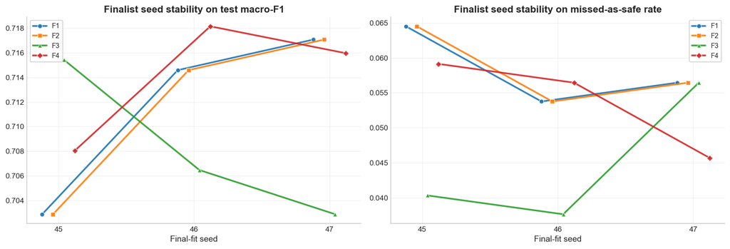

**Graph note**

These lines show whether finalist behavior is steady across final-fit seeds or driven by a few spiky runs.

How to read it: Flatter lines suggest a finalist is seed-stable. Large up-and-down movement means the same recipe can look much stronger or weaker depending on seed, which should temper confidence in small aggregate gaps.

This is a recipe-level seed-stability view; the full shortlist decision still uses the saved aggregate artifacts. Small horizontal offsets are added only so coincident seed points remain visible.

```
    **Finding.** The finalist table is not just a story of mean performance. The per-seed spread shows which recipes are steady versus spiky,
    while the CV-side peak-drop audit shows whether earlier success relied on narrow best-epoch peaks. In this artifact set, the steadiest finalist by seed-level macro spread is `F4`,
    while the most variable is `F1`. The cross-check table above also shows that the notebook's recomputed finalist metrics line up with the saved extra-audit summary,
    so the later audit sections can safely reuse those saved artifacts without changing the underlying metric story.
```

```python
finalist_aggregate_rows = []
for finalist in finalists_payload["finalists"]:
    agg = finalist["aggregate"]
    finalist_aggregate_rows.append(
        {
            "finalist_rank": int(finalist["finalist_rank"]),
            "spec_signature": finalist["spec_signature"],
            "member_count": len(finalist["members"]),
            "val_macro_f1_mean": agg["val_macro_f1_mean"],
            "val_macro_f1_std": agg["val_macro_f1_std"],
            "test_macro_f1_mean": agg["test_macro_f1_mean"],
            "test_macro_f1_std": agg["test_macro_f1_std"],
            "test_unsafe_macro_f1_mean": agg["test_unsafe_macro_f1_mean"],
            "test_missed_as_safe_rate_mean": agg["test_missed_as_safe_rate_mean"],
        }
    )
finalist_aggregate_df = pd.DataFrame(finalist_aggregate_rows).sort_values("finalist_rank").reset_index(drop=True)
display(finalist_aggregate_df)

finalist_prob_map_val, ensemble_targets_val, per_seed_val_df = load_finalist_probabilities(split="val")
finalist_prob_map_test, ensemble_targets_test, per_seed_test_df = load_finalist_probabilities(split="test")

single_model_rows = []
for rank, probs in sorted(finalist_prob_map_test.items()):
    metrics = metric_dict_from_probs(probs, ensemble_targets_test)
    single_model_rows.append(
        {
            "finalist_rank": rank,
            "macro_f1": metrics["macro_f1"],
            "weighted_f1": metrics["weighted_f1"],
            "unsafe_macro_f1": metrics["unsafe_macro_f1"],
            "unsafe_recall": metrics["unsafe_recall"],
            "missed_as_safe_rate": metrics["missed_as_safe_rate"],
            "ece": metrics["ece"],
            "brier": metrics["brier"],
        }
    )
single_model_df = pd.DataFrame(single_model_rows).sort_values("finalist_rank").reset_index(drop=True)
display(Markdown("**Seed-ensemble test metrics per finalist recipe**"))
display(single_model_df)

audit_finalist_df = (
    audit_model_summary_df[audit_model_summary_df["type"] == "finalist"].copy()
    .assign(finalist_rank=lambda df_: df_["model"].str.extract(r"(\d+)")[0].astype(int))
    .sort_values("finalist_rank")
    .reset_index(drop=True)
)
finalist_crosscheck_df = (
    single_model_df.merge(
        audit_finalist_df[["finalist_rank", "macro_f1", "unsafe_macro_f1", "missed_as_safe_rate", "ece"]].rename(
            columns={
                "macro_f1": "audit_macro_f1",
                "unsafe_macro_f1": "audit_unsafe_macro_f1",
                "missed_as_safe_rate": "audit_missed_as_safe_rate",
                "ece": "audit_ece",
            }
        ),
        on="finalist_rank",
        how="left",
    )
    .assign(
        macro_delta_vs_audit=lambda df_: df_["macro_f1"] - df_["audit_macro_f1"],
        unsafe_delta_vs_audit=lambda df_: df_["unsafe_macro_f1"] - df_["audit_unsafe_macro_f1"],
        missed_safe_delta_vs_audit=lambda df_: df_["missed_as_safe_rate"] - df_["audit_missed_as_safe_rate"],
        ece_delta_vs_audit=lambda df_: df_["ece"] - df_["audit_ece"],
    )
)
display(Markdown("**Appendix-style consistency block: cross-check against the saved extra-audit finalist summary**"))
display(finalist_crosscheck_df)

seed_spread_df = (
    per_seed_test_df.groupby("finalist_rank")
    .agg(
        seed_count=("seed", "nunique"),
        macro_mean=("macro_f1", "mean"),
        macro_std=("macro_f1", "std"),
        macro_min=("macro_f1", "min"),
        macro_max=("macro_f1", "max"),
        missed_safe_mean=("missed_as_safe_rate", "mean"),
        missed_safe_std=("missed_as_safe_rate", "std"),
        ece_mean=("ece", "mean"),
    )
    .reset_index()
)
display(Markdown("**Per-seed spread behind each finalist**"))
display(seed_spread_df)

finalist_cv_rows = []
for finalist in finalists_payload["finalists"]:
    sig = finalist["spec_signature"]
    cv_sub = cv_results[(cv_results["spec_signature"] == sig) & (cv_results["stage"] == "s11_rob")].copy()
    if cv_sub.empty:
        cv_sub = cv_results[cv_results["spec_signature"] == sig].copy()
    run_summaries = pd.DataFrame([summarize_run_dynamics(run_name) for run_name in cv_sub["run_name"].drop_duplicates().tolist()])
    finalist_cv_rows.append(
        {
            "finalist_rank": int(finalist["finalist_rank"]),
            "cv_runs_available": int(len(cv_sub)),
            "cv_macro_mean": float(cv_sub["val_macro_f1"].mean()) if len(cv_sub) else np.nan,
            "cv_macro_std": float(cv_sub["val_macro_f1"].std(ddof=1)) if len(cv_sub) > 1 else np.nan,
            "cv_best_epoch_mean": float(run_summaries["best_epoch"].mean()) if "best_epoch" in run_summaries.columns else np.nan,
            "cv_peak_epoch_mean": float(run_summaries["val_peak_epoch"].mean()) if "val_peak_epoch" in run_summaries.columns else np.nan,
            "cv_peak_drop_mean": float(run_summaries["val_peak_drop"].mean()) if "val_peak_drop" in run_summaries.columns else np.nan,
            "cv_peak_drop_max": float(run_summaries["val_peak_drop"].max()) if "val_peak_drop" in run_summaries.columns else np.nan,
        }
    )
finalist_cv_stability_df = pd.DataFrame(finalist_cv_rows).sort_values("finalist_rank").reset_index(drop=True)
display(Markdown("**CV-side stability signals for finalist recipes**"))
display(finalist_cv_stability_df)

fig, axes = plt.subplots(1, 2, figsize=(13.6, 4.7))
color_cycle = plt.rcParams["axes.prop_cycle"].by_key().get("color", [])
marker_cycle = ["o", "s", "^", "D", "P", "X", "v", "<", ">", "*"]
finalist_ranks = sorted(per_seed_test_df["finalist_rank"].unique().tolist())
seed_offsets = np.linspace(-0.12, 0.12, len(finalist_ranks)) if len(finalist_ranks) > 1 else np.array([0.0])
for idx, (rank, sub) in enumerate(per_seed_test_df.groupby("finalist_rank")):
    sub = sub.sort_values("seed")
    color = color_cycle[idx % len(color_cycle)] if color_cycle else None
    marker = marker_cycle[idx % len(marker_cycle)]
    x = sub["seed"].astype(float) + float(seed_offsets[idx])
    axes[0].plot(
        x,
        sub["macro_f1"],
        marker=marker,
        label=f"F{rank}",
        color=color,
        linewidth=2.2,
        markersize=6,
        markeredgecolor="white",
        markeredgewidth=0.7,
        alpha=0.9,
    )
    axes[1].plot(
        x,
        sub["missed_as_safe_rate"],
        marker=marker,
        label=f"F{rank}",
        color=color,
        linewidth=2.2,
        markersize=6,
        markeredgecolor="white",
        markeredgewidth=0.7,
        alpha=0.9,
    )
axes[0].set_title("Finalist seed stability on test macro-F1")
axes[1].set_title("Finalist seed stability on missed-as-safe rate")
seed_ticks = sorted(per_seed_test_df["seed"].unique().tolist())
for ax in axes:
    ax.set_xlabel("Final-fit seed")
    ax.set_xticks(seed_ticks)
    ax.legend()
fig.tight_layout()
plt.show()
plt.close(fig)
display_note(
    title="Graph note",
    purpose="These lines show whether finalist behavior is steady across final-fit seeds or driven by a few spiky runs.",
    how_to_read="Flatter lines suggest a finalist is seed-stable. Large up-and-down movement means the same recipe can look much stronger or weaker depending on seed, which should temper confidence in small aggregate gaps.",
    caveat="This is a recipe-level seed-stability view; the full shortlist decision still uses the saved aggregate artifacts. Small horizontal offsets are added only so coincident seed points remain visible."
)

steadiest_rank = int(seed_spread_df.sort_values(["macro_std", "macro_mean"], ascending=[True, False]).iloc[0]["finalist_rank"])
spikiest_rank = int(seed_spread_df.sort_values(["macro_std", "macro_mean"], ascending=[False, False]).iloc[0]["finalist_rank"])
display(
    Markdown(
        f'''
        **Finding.** The finalist table is not just a story of mean performance. The per-seed spread shows which recipes are steady versus spiky,
        while the CV-side peak-drop audit shows whether earlier success relied on narrow best-epoch peaks. In this artifact set, the steadiest finalist by seed-level macro spread is `F{steadiest_rank}`,
        while the most variable is `F{spikiest_rank}`. The cross-check table above also shows that the notebook's recomputed finalist metrics line up with the saved extra-audit summary,
        so the later audit sections can safely reuse those saved artifacts without changing the underlying metric story.
        '''
    )
)
```

### Best-Epoch And Training-Dynamics Audit

Search-stage runs include validation curves, so they can reveal overfitting, narrow peaks, and plateau behavior. Final-fit runs are train-only, so they are interpreted differently and kept separate here.

**Focused curve audit: Stage 2: Output Mode**

|  | stage | run_name | best_epoch | epochs_ran | splits | val_peak_epoch | val_peak_macro | val_peak_drop | val_end_macro | train_end_macro | val_end_loss | train_end_loss | best_val_macro | best_val_unsafe_macro | best_val_missed_safe |
| --- | --- | --- | --- | --- | --- | --- | --- | --- | --- | --- | --- | --- | --- | --- | --- |
| 0 | s2_om | cv_beam_v3__s2_om__bb-L14b82__fu-it__hd-ln__om-fah__pd-512__ls-ce__cw-ef__bt-0p999__sp-sh__lr-0p001__wd-0p0001__ab-0p0__au-0p0__f01__s40 | 6 | 10 | train,val | 6 | 0.762849 | 0.018904 | 0.743945 | 0.966328 | 0.759251 | 0.097130 | 0.762849 | 0.786762 | 0.049133 |
| 1 | s2_om | cv_beam_v3__s2_om__bb-L14b82__fu-it__hd-ln__om-fl__pd-512__ls-ce__cw-ef__bt-0p999__sp-sh__lr-0p001__wd-0p0001__f01__s40 | 6 | 10 | train,val | 6 | 0.766946 | 0.014404 | 0.752542 | 0.966118 | 0.770930 | 0.094861 | 0.766946 | 0.789971 | 0.052023 |
| 2 | s2_om | cv_beam_v3__s2_om__bb-L14b82__fu-it__hd-ln__om-hi__pd-512__ls-ce__cw-ef__bt-0p999__sp-sh__lr-0p001__wd-0p0001__lu-1p0__f01__s40 | 6 | 10 | train,val | 6 | 0.751838 | 0.022214 | 0.729624 | 0.977601 | 1.010636 | 0.116062 | 0.751838 | 0.775350 | 0.075145 |

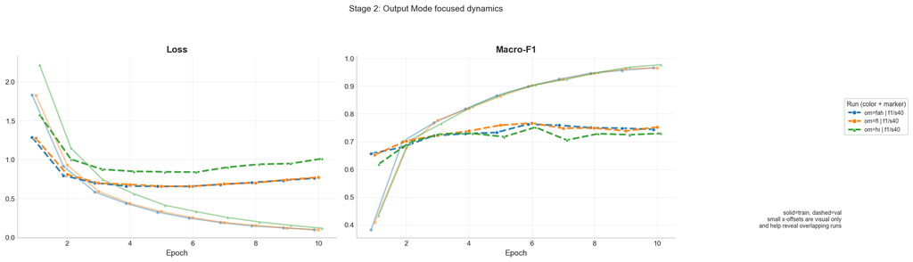

**Graph note**

This curve pair shows training dynamics for a small set of representative raw runs, so the goal is to understand *how* a candidate wins or loses, not to restate the aggregate selection rule.

How to read it: The left panel tracks loss by epoch and split; widening train-vs-val separation suggests overfitting. The right panel tracks validation-facing macro-F1 behavior; sharp early peaks followed by decline suggest unstable best-epoch wins, while flatter curves suggest more stable generalization.

Only one or a few representative fold/seed runs are shown here for readability. The actual stage ranking still comes from the full fold/seed aggregate, while these plots provide concrete run-level evidence for the interpretation. Small horizontal offsets are added only to keep nearly overlapping runs visible.

**Focused curve audit: Stage 10: Optimizer Sweep**

|  | stage | run_name | best_epoch | epochs_ran | splits | val_peak_epoch | val_peak_macro | val_peak_drop | val_end_macro | train_end_macro | val_end_loss | train_end_loss | best_val_macro | best_val_unsafe_macro | best_val_missed_safe |
| --- | --- | --- | --- | --- | --- | --- | --- | --- | --- | --- | --- | --- | --- | --- | --- |
| 0 | s10_opt | cv_beam_v3__s10_opt__bb-L14b82__fu-it__hd-ln__om-fah__pd-256__ls-ce__cw-ef__bt-0p999__sp-sh__lr-0p001__wd-0p0001__ab-0p25__au-0p0__f01__s42 | 6 | 10 | train,val | 6 | 0.765298 | 0.023537 | 0.741761 | 0.944779 | 0.790075 | 0.180455 | 0.765298 | 0.796871 | 0.046243 |
| 1 | s10_opt | cv_beam_v3__s10_opt__bb-L14b82__fu-it__hd-ln__om-fah__pd-256__ls-ce__cw-ef__bt-0p999__sp-sh__lr-0p001__wd-0p0005__ab-0p25__au-0p0__f01__s42 | 6 | 10 | train,val | 6 | 0.765298 | 0.023537 | 0.741761 | 0.944492 | 0.789957 | 0.180505 | 0.765298 | 0.796871 | 0.046243 |

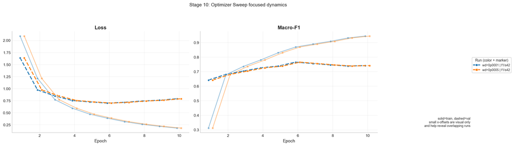

**Graph note**

This curve pair shows training dynamics for a small set of representative raw runs, so the goal is to understand *how* a candidate wins or loses, not to restate the aggregate selection rule.

How to read it: The left panel tracks loss by epoch and split; widening train-vs-val separation suggests overfitting. The right panel tracks validation-facing macro-F1 behavior; sharp early peaks followed by decline suggest unstable best-epoch wins, while flatter curves suggest more stable generalization.

Only one or a few representative fold/seed runs are shown here for readability. The actual stage ranking still comes from the full fold/seed aggregate, while these plots provide concrete run-level evidence for the interpretation. Small horizontal offsets are added only to keep nearly overlapping runs visible.

**Focused curve audit: Stage 11: Robustness Rerun**

|  | stage | run_name | best_epoch | epochs_ran | splits | val_peak_epoch | val_peak_macro | val_peak_drop | val_end_macro | train_end_macro | val_end_loss | train_end_loss | best_val_macro | best_val_unsafe_macro | best_val_missed_safe |
| --- | --- | --- | --- | --- | --- | --- | --- | --- | --- | --- | --- | --- | --- | --- | --- |
| 0 | s11_rob | cv_beam_v3__s11_rob__bb-L14b82__fu-it__hd-ln__om-fah__pd-256__ls-ce__cw-ef__bt-0p999__sp-sh__lr-0p001__wd-0p0001__ab-0p25__au-0p0__f01__s43 | 9 | 13 | train,val | 9 | 0.76924 | 0.025788 | 0.743452 | 0.972317 | 0.848058 | 0.111604 | 0.76924 | 0.793738 | 0.049133 |
| 1 | s11_rob | cv_beam_v3__s11_rob__bb-L14b82__fu-it__hd-ln__om-fah__pd-256__ls-ce__cw-ef__bt-0p999__sp-sh__lr-0p001__wd-0p0005__ab-0p25__au-0p0__f01__s43 | 9 | 13 | train,val | 9 | 0.76924 | 0.025788 | 0.743452 | 0.972317 | 0.847976 | 0.111626 | 0.76924 | 0.793738 | 0.049133 |

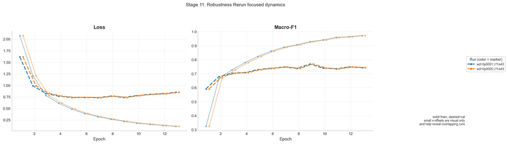

**Graph note**

This curve pair shows training dynamics for a small set of representative raw runs, so the goal is to understand *how* a candidate wins or loses, not to restate the aggregate selection rule.

How to read it: The left panel tracks loss by epoch and split; widening train-vs-val separation suggests overfitting. The right panel tracks validation-facing macro-F1 behavior; sharp early peaks followed by decline suggest unstable best-epoch wins, while flatter curves suggest more stable generalization.

Only one or a few representative fold/seed runs are shown here for readability. The actual stage ranking still comes from the full fold/seed aggregate, while these plots provide concrete run-level evidence for the interpretation. Small horizontal offsets are added only to keep nearly overlapping runs visible.

**Robustness-stage best-epoch summary**

|  | n_runs | best_epoch_mean | best_epoch_std | peak_drop_mean | peak_drop_90pct |
| --- | --- | --- | --- | --- | --- |
| 0 | 150 | 8.953333 | 2.869269 | 0.013387 | 0.025145 |

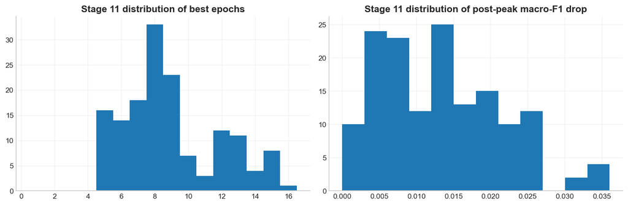

**Graph note**

These histograms summarize where late-stage runs found their best epoch and how much performance dropped after the peak.

How to read it: A best-epoch distribution concentrated very early can indicate rapid overfitting. Larger peak-drop values mean a recipe often looks best only briefly before validation performance declines.

This is a late-stage audit of training dynamics, not a replacement for the stage-selection metrics.

**Final-fit runs (train-only logs, interpreted separately)**

|  | run_name | best_epoch | epochs_ran | splits | train_start_loss | train_end_loss | train_start_macro | train_end_macro | train_end_acc | finalist_rank |
| --- | --- | --- | --- | --- | --- | --- | --- | --- | --- | --- |
| 0 | cv_beam_v3__m1__bb-L14b82__fu-it__hd-ln__om-fah__pd-256__ls-ce__cw-ef__bt-0p999__sp-sh__lr-0p001__wd-0p0001__ab-0p25__au-0p0__s45 | 8 | 8 | train | 1.967188 | 0.246082 | 0.341079 | 0.920836 | 0.932873 | 1 |
| 1 | cv_beam_v3__m2__bb-L14b82__fu-it__hd-ln__om-fah__pd-256__ls-ce__cw-ef__bt-0p999__sp-sh__lr-0p001__wd-0p0005__ab-0p25__au-0p0__s45 | 8 | 8 | train | 1.967191 | 0.246102 | 0.341079 | 0.920965 | 0.933187 | 2 |
| 2 | cv_beam_v3__m3__bb-L14b82__fu-it__hd-ln__om-fah__pd-256__ls-ce__cw-ef__bt-0p999__sp-sh__lr-0p0005__wd-0p0001__ab-0p25__au-0p0__s45 | 12 | 12 | train | 2.204210 | 0.300889 | 0.143642 | 0.899611 | 0.919072 | 3 |
| 3 | cv_beam_v3__m4__bb-L14b82__fu-it__hd-ln__om-fah__pd-256__ls-ce__cw-ef__bt-0p999__sp-sh__lr-0p001__wd-0p0001__ab-0p5__au-0p25__s45 | 8 | 8 | train | 2.545902 | 0.325874 | 0.340911 | 0.915598 | 0.928795 | 4 |

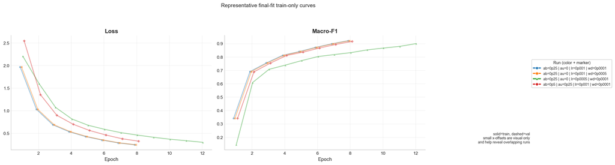

**Graph note**

This curve pair shows training dynamics for a small set of representative raw runs, so the goal is to understand *how* a candidate wins or loses, not to restate the aggregate selection rule.

How to read it: The left panel tracks loss by epoch and split; widening train-vs-val separation suggests overfitting. The right panel tracks validation-facing macro-F1 behavior; sharp early peaks followed by decline suggest unstable best-epoch wins, while flatter curves suggest more stable generalization.

Only one or a few representative fold/seed runs are shown here for readability. The actual stage ranking still comes from the full fold/seed aggregate, while these plots provide concrete run-level evidence for the interpretation. Small horizontal offsets are added only to keep nearly overlapping runs visible.

```
    **Finding.** The CV-search runs and final-fit runs tell different stories and should not be mixed. Search runs expose whether a recipe wins through stable validation behavior or a sharp peak,
    while final-fit runs only confirm how the chosen recipes optimized on the full training split. The Stage 11 peak-drop summary suggests how much overfitting pressure remained in the late frontier:
    average post-peak drop was about 0.0134 macro-F1 on the robustness-stage runs.
```

```python
focus_stage_names = ["s2_om", "s10_opt", "s11_rob"]
focus_stage_dfs = []
for stage_name in focus_stage_names:
    rep_runs = stage_representative_runs.get(stage_name, [])
    if not rep_runs:
        matched = winner_matched_group(stage_name, stage_df(stage_name))
        for sig in matched["spec_signature"].head(2).tolist():
            run_subset = (
                cv_results[(cv_results["stage"] == stage_name) & (cv_results["spec_signature"] == sig)]
                .sort_values("val_macro_f1", ascending=False)
                .reset_index(drop=True)
            )
            if not run_subset.empty:
                rep_runs.append(run_subset.iloc[0]["run_name"])
        rep_runs = list(dict.fromkeys(rep_runs))
    display(Markdown(f"**Focused curve audit: {STAGE_TITLES[stage_name]}**"))
    focus_df = run_evidence_table(rep_runs)
    focus_df.insert(0, "stage", stage_name)
    focus_stage_dfs.append(focus_df)
    display(focus_df)
    try:
        plot_run_curves(rep_runs, title=f"{STAGE_TITLES[stage_name]} focused dynamics")
    except Exception as exc:
        display(Markdown(f"_Focused curve plot skipped: {exc}_"))

focus_run_table_df = pd.concat(focus_stage_dfs, ignore_index=True)

rob_run_summaries = pd.DataFrame(
    [summarize_run_dynamics(run_name) for run_name in cv_results[cv_results["stage"] == "s11_rob"]["run_name"].drop_duplicates().tolist()]
)
rob_epoch_summary_df = pd.DataFrame(
    [
        {
            "n_runs": int(len(rob_run_summaries)),
            "best_epoch_mean": float(rob_run_summaries["best_epoch"].mean()),
            "best_epoch_std": float(rob_run_summaries["best_epoch"].std(ddof=1)),
            "peak_drop_mean": float(rob_run_summaries["val_peak_drop"].mean()),
            "peak_drop_90pct": float(rob_run_summaries["val_peak_drop"].quantile(0.9)),
        }
    ]
)
display(Markdown("**Robustness-stage best-epoch summary**"))
display(rob_epoch_summary_df)

fig, axes = plt.subplots(1, 2, figsize=(12, 4))
axes[0].hist(rob_run_summaries["best_epoch"].dropna(), bins=np.arange(0.5, rob_run_summaries["best_epoch"].max() + 1.5, 1))
axes[0].set_title("Stage 11 distribution of best epochs")
axes[1].hist(rob_run_summaries["val_peak_drop"].dropna(), bins=12)
axes[1].set_title("Stage 11 distribution of post-peak macro-F1 drop")
plt.tight_layout()
plt.show()
plt.close(fig)
display_note(
    title="Graph note",
    purpose="These histograms summarize where late-stage runs found their best epoch and how much performance dropped after the peak.",
    how_to_read="A best-epoch distribution concentrated very early can indicate rapid overfitting. Larger peak-drop values mean a recipe often looks best only briefly before validation performance declines.",
    caveat="This is a late-stage audit of training dynamics, not a replacement for the stage-selection metrics."
)

final_fit_rows = []
final_fit_rep_runs = []
for finalist in finalists_payload["finalists"]:
    run_name = finalist["members"][0]["run_name"]
    final_fit_rep_runs.append(run_name)
    info = summarize_run_dynamics(run_name)
    info["finalist_rank"] = int(finalist["finalist_rank"])
    final_fit_rows.append(info)
final_fit_train_df = pd.DataFrame(final_fit_rows).sort_values("finalist_rank").reset_index(drop=True)
display(Markdown("**Final-fit runs (train-only logs, interpreted separately)**"))
display(final_fit_train_df)
try:
    plot_run_curves(final_fit_rep_runs, title="Representative final-fit train-only curves")
except Exception as exc:
    display(Markdown(f"_Final-fit curve plot skipped: {exc}_"))

overfit_signal = float(rob_run_summaries["val_peak_drop"].mean())
display(
    Markdown(
        f'''
        **Finding.** The CV-search runs and final-fit runs tell different stories and should not be mixed. Search runs expose whether a recipe wins through stable validation behavior or a sharp peak,
        while final-fit runs only confirm how the chosen recipes optimized on the full training split. The Stage 11 peak-drop summary suggests how much overfitting pressure remained in the late frontier:
        average post-peak drop was about {overfit_signal:.4f} macro-F1 on the robustness-stage runs.
        '''
    )
)
```

### Ensemble And Redundancy Diagnostics

The ensemble should earn its keep. This section checks whether the full ensemble improves on the strongest single finalist, which members contribute complementary signal, and which look redundant under leave-one-member-out and shared-error analysis.

```python
ensemble_probs_test, ensemble_targets_test, finalist_prob_map_test, _ = full_ensemble_probs(split="test")
ensemble_metrics = metric_dict_from_probs(ensemble_probs_test, ensemble_targets_test)

ensemble_eval_rows = [
    {
        "model": "ensemble_all",
        "macro_f1": ensemble_metrics["macro_f1"],
        "weighted_f1": ensemble_metrics["weighted_f1"],
        "unsafe_macro_f1": ensemble_metrics["unsafe_macro_f1"],
        "unsafe_recall": ensemble_metrics["unsafe_recall"],
        "missed_as_safe_rate": ensemble_metrics["missed_as_safe_rate"],
        "ece": ensemble_metrics["ece"],
        "brier": ensemble_metrics["brier"],
    }
]
for rank, probs in sorted(finalist_prob_map_test.items()):
    metrics = metric_dict_from_probs(probs, ensemble_targets_test)
    ensemble_eval_rows.append(
        {
            "model": f"finalist_{rank}",
            "macro_f1": metrics["macro_f1"],
            "weighted_f1": metrics["weighted_f1"],
            "unsafe_macro_f1": metrics["unsafe_macro_f1"],
            "unsafe_recall": metrics["unsafe_recall"],
            "missed_as_safe_rate": metrics["missed_as_safe_rate"],
            "ece": metrics["ece"],
            "brier": metrics["brier"],
        }
    )
ensemble_eval_df = pd.DataFrame(ensemble_eval_rows)
display(ensemble_eval_df)

audit_ensemble_metrics_df = audit_model_summary_df.copy()
audit_ensemble_metrics_df["model_key"] = audit_ensemble_metrics_df["model"]
ensemble_mask = audit_ensemble_metrics_df["type"] == "ensemble"
audit_ensemble_metrics_df.loc[ensemble_mask, "model_key"] = "ensemble_all"
audit_ensemble_metrics_df.loc[~ensemble_mask, "model_key"] = (
    "finalist_" + audit_ensemble_metrics_df.loc[~ensemble_mask, "model"].str.extract(r"(\d+)")[0]
)
ensemble_crosscheck_df = (
    ensemble_eval_df.merge(
        audit_ensemble_metrics_df[["model_key", "macro_f1", "unsafe_macro_f1", "missed_as_safe_rate", "ece"]].rename(
            columns={
                "model_key": "model",
                "macro_f1": "audit_macro_f1",
                "unsafe_macro_f1": "audit_unsafe_macro_f1",
                "missed_as_safe_rate": "audit_missed_as_safe_rate",
                "ece": "audit_ece",
            }
        ),
        on="model",
        how="left",
    )
    .assign(
        macro_delta_vs_audit=lambda df_: df_["macro_f1"] - df_["audit_macro_f1"],
        unsafe_delta_vs_audit=lambda df_: df_["unsafe_macro_f1"] - df_["audit_unsafe_macro_f1"],
        missed_safe_delta_vs_audit=lambda df_: df_["missed_as_safe_rate"] - df_["audit_missed_as_safe_rate"],
        ece_delta_vs_audit=lambda df_: df_["ece"] - df_["audit_ece"],
    )
)
display(Markdown("**Appendix-style consistency block: cross-check against the saved extra-audit ensemble / finalist metrics**"))
display(ensemble_crosscheck_df)

loo_rows = []
for rank in sorted(finalist_prob_map_test):
    loo_probs, loo_targets, _, _ = full_ensemble_probs(split="test", leave_out=rank)
    loo_metrics = metric_dict_from_probs(loo_probs, loo_targets)
    loo_rows.append(
        {
            "removed_finalist": rank,
            "macro_f1": loo_metrics["macro_f1"],
            "weighted_f1": loo_metrics["weighted_f1"],
            "unsafe_macro_f1": loo_metrics["unsafe_macro_f1"],
            "unsafe_recall": loo_metrics["unsafe_recall"],
            "missed_as_safe_rate": loo_metrics["missed_as_safe_rate"],
            "ece": loo_metrics["ece"],
            "brier": loo_metrics["brier"],
            "delta_macro_vs_full": loo_metrics["macro_f1"] - ensemble_metrics["macro_f1"],
            "delta_missed_safe_vs_full": loo_metrics["missed_as_safe_rate"] - ensemble_metrics["missed_as_safe_rate"],
        }
    )
loo_eval_df = pd.DataFrame(loo_rows).sort_values("removed_finalist").reset_index(drop=True)
display(Markdown("**Leave-one-member-out ensemble stress test**"))
display(loo_eval_df)
loo_crosscheck_df = (
    loo_eval_df.merge(
        audit_loo_df.rename(
            columns={
                "macro_f1": "audit_macro_f1",
                "unsafe_macro_f1": "audit_unsafe_macro_f1",
                "missed_as_safe_rate": "audit_missed_as_safe_rate",
            }
        ),
        on="removed_finalist",
        how="left",
    )
    .assign(
        macro_delta_vs_audit=lambda df_: df_["macro_f1"] - df_["audit_macro_f1"],
        unsafe_delta_vs_audit=lambda df_: df_["unsafe_macro_f1"] - df_["audit_unsafe_macro_f1"],
        missed_safe_delta_vs_audit=lambda df_: df_["missed_as_safe_rate"] - df_["audit_missed_as_safe_rate"],
    )
)
display(Markdown("**Appendix-style consistency block: cross-check against the saved leave-one-out audit table**"))
display(loo_crosscheck_df)

overlap_df = pairwise_overlap_table(finalist_prob_map_test, ensemble_targets_test)
display(Markdown("**Pairwise disagreement and shared-error overlap among finalists**"))
display(overlap_df)
overlap_crosscheck_df = (
    overlap_df.merge(
        audit_pairwise_df.rename(
            columns={
                "pred_disagreement_rate": "audit_pred_disagreement_rate",
                "shared_error_rate": "audit_shared_error_rate",
                "shared_unsafe_to_safe_rate": "audit_shared_unsafe_to_safe_rate",
            }
        ),
        on=["a", "b"],
        how="left",
    )
    .assign(
        disagreement_delta_vs_audit=lambda df_: df_["pred_disagreement_rate"] - df_["audit_pred_disagreement_rate"],
        shared_error_delta_vs_audit=lambda df_: df_["shared_error_rate"] - df_["audit_shared_error_rate"],
        shared_unsafe_safe_delta_vs_audit=lambda df_: df_["shared_unsafe_to_safe_rate"] - df_["audit_shared_unsafe_to_safe_rate"],
    )
)
display(Markdown("**Appendix-style consistency block: cross-check against the saved pairwise redundancy audit**"))
display(overlap_crosscheck_df[[
    "a",
    "b",
    "pred_disagreement_rate",
    "audit_pred_disagreement_rate",
    "disagreement_delta_vs_audit",
    "shared_error_rate",
    "audit_shared_error_rate",
    "shared_error_delta_vs_audit",
]])

most_redundant_pair = overlap_df.sort_values(["pred_disagreement_rate", "shared_error_rate"], ascending=[True, False]).iloc[0]
most_helpful_removal = loo_eval_df.sort_values("delta_macro_vs_full").iloc[0]
best_single_macro = float(single_model_df["macro_f1"].max())
complementarity_text = "mostly averaging near-duplicates" if abs(ensemble_metrics["macro_f1"] - best_single_macro) <= 0.0015 else "showing meaningful complementarity beyond simple averaging"
display(
    Markdown(
        f'''
        **Plain-English summary.** The most redundant-looking pair is `F{int(most_redundant_pair["a"])}` and `F{int(most_redundant_pair["b"])}`:
        they disagree on only {most_redundant_pair["pred_disagreement_count"]}/{int(most_redundant_pair["n_samples"])} test cases ({most_redundant_pair["pred_disagreement_rate"]:.4f}) and share an error rate of {most_redundant_pair["shared_error_rate"]:.4f}.
        The finalist that adds the most marginal value under leave-one-out is `F{int(most_helpful_removal["removed_finalist"])}`, because removing it changes ensemble macro-F1 by {most_helpful_removal["delta_macro_vs_full"]:+.4f}.
        Overall, the ensemble gain looks like {complementarity_text}: there is some real error correction, but a noticeable part of the averaging pool is still redundant.
        '''
    )
)
```

|  | model | macro_f1 | weighted_f1 | unsafe_macro_f1 | unsafe_recall | missed_as_safe_rate | ece | brier |
| --- | --- | --- | --- | --- | --- | --- | --- | --- |
| 0 | ensemble_all | 0.706373 | 0.797752 | 0.718669 | 0.943548 | 0.056452 | 0.031393 | 0.282750 |
| 1 | finalist_1 | 0.705920 | 0.797754 | 0.718047 | 0.943548 | 0.056452 | 0.033327 | 0.281992 |
| 2 | finalist_2 | 0.705920 | 0.797754 | 0.718047 | 0.943548 | 0.056452 | 0.033325 | 0.282016 |
| 3 | finalist_3 | 0.708331 | 0.801598 | 0.717664 | 0.956989 | 0.043011 | 0.029597 | 0.286530 |
| 4 | finalist_4 | 0.702938 | 0.795181 | 0.716546 | 0.943548 | 0.056452 | 0.034136 | 0.282749 |

**Appendix-style consistency block: cross-check against the saved extra-audit ensemble / finalist metrics**

|  | model | macro_f1 | weighted_f1 | unsafe_macro_f1 | unsafe_recall | missed_as_safe_rate | ece | brier | audit_macro_f1 | audit_unsafe_macro_f1 | audit_missed_as_safe_rate | audit_ece | macro_delta_vs_audit | unsafe_delta_vs_audit | missed_safe_delta_vs_audit | ece_delta_vs_audit |
| --- | --- | --- | --- | --- | --- | --- | --- | --- | --- | --- | --- | --- | --- | --- | --- | --- |
| 0 | ensemble_all | 0.706373 | 0.797752 | 0.718669 | 0.943548 | 0.056452 | 0.031393 | 0.282750 | 0.706373 | 0.718669 | 0.056452 | 0.031393 | 0.0 | 0.0 | 6.938894e-18 | -1.189479e-08 |
| 1 | finalist_1 | 0.705920 | 0.797754 | 0.718047 | 0.943548 | 0.056452 | 0.033327 | 0.281992 | 0.705920 | 0.718047 | 0.056452 | 0.033327 | 0.0 | 0.0 | 6.938894e-18 | -2.701380e-09 |
| 2 | finalist_2 | 0.705920 | 0.797754 | 0.718047 | 0.943548 | 0.056452 | 0.033325 | 0.282016 | 0.705920 | 0.718047 | 0.056452 | 0.033325 | 0.0 | 0.0 | 6.938894e-18 | 2.775558e-17 |
| 3 | finalist_3 | 0.708331 | 0.801598 | 0.717664 | 0.956989 | 0.043011 | 0.029597 | 0.286530 | 0.708331 | 0.717664 | 0.043011 | 0.029597 | 0.0 | 0.0 | 4.857226e-17 | 1.387779e-17 |
| 4 | finalist_4 | 0.702938 | 0.795181 | 0.716546 | 0.943548 | 0.056452 | 0.034136 | 0.282749 | 0.702938 | 0.716546 | 0.056452 | 0.034136 | 0.0 | 0.0 | 6.938894e-18 | 1.089266e-09 |

**Leave-one-member-out ensemble stress test**

|  | removed_finalist | macro_f1 | weighted_f1 | unsafe_macro_f1 | unsafe_recall | missed_as_safe_rate | ece | brier | delta_macro_vs_full | delta_missed_safe_vs_full |
| --- | --- | --- | --- | --- | --- | --- | --- | --- | --- | --- |
| 0 | 1 | 0.702913 | 0.794875 | 0.714564 | 0.943548 | 0.056452 | 0.033740 | 0.283102 | -0.003460 | 0.000000 |
| 1 | 2 | 0.702913 | 0.794875 | 0.714564 | 0.943548 | 0.056452 | 0.033738 | 0.283095 | -0.003460 | 0.000000 |
| 2 | 3 | 0.708566 | 0.799446 | 0.721050 | 0.946237 | 0.053763 | 0.034172 | 0.282201 | 0.002193 | -0.002688 |
| 3 | 4 | 0.701654 | 0.794884 | 0.712977 | 0.943548 | 0.056452 | 0.038624 | 0.282854 | -0.004719 | 0.000000 |

**Appendix-style consistency block: cross-check against the saved leave-one-out audit table**

|  | removed_finalist | macro_f1 | weighted_f1_x | unsafe_macro_f1 | unsafe_recall_x | missed_as_safe_rate | ece_x | brier_x | delta_macro_vs_full_x | delta_missed_safe_vs_full_x | audit_macro_f1 | weighted_f1_y | audit_unsafe_macro_f1 | unsafe_recall_y | audit_missed_as_safe_rate | ece_y | brier_y | delta_macro_vs_full_y | delta_missed_safe_vs_full_y | macro_delta_vs_audit | unsafe_delta_vs_audit | missed_safe_delta_vs_audit |
| --- | --- | --- | --- | --- | --- | --- | --- | --- | --- | --- | --- | --- | --- | --- | --- | --- | --- | --- | --- | --- | --- | --- |
| 0 | 1 | 0.702913 | 0.794875 | 0.714564 | 0.943548 | 0.056452 | 0.033740 | 0.283102 | -0.003460 | 0.000000 | 0.702913 | 0.794875 | 0.714564 | 0.943548 | 0.056452 | 0.033740 | 0.283102 | -0.003460 | 0.000000 | 0.0 | 0.0 | 6.938894e-18 |
| 1 | 2 | 0.702913 | 0.794875 | 0.714564 | 0.943548 | 0.056452 | 0.033738 | 0.283095 | -0.003460 | 0.000000 | 0.702913 | 0.794875 | 0.714564 | 0.943548 | 0.056452 | 0.033738 | 0.283095 | -0.003460 | 0.000000 | 0.0 | 0.0 | 6.938894e-18 |
| 2 | 3 | 0.708566 | 0.799446 | 0.721050 | 0.946237 | 0.053763 | 0.034172 | 0.282201 | 0.002193 | -0.002688 | 0.708566 | 0.799446 | 0.721050 | 0.946237 | 0.053763 | 0.034172 | 0.282201 | 0.002193 | -0.002688 | 0.0 | 0.0 | 5.551115e-17 |
| 3 | 4 | 0.701654 | 0.794884 | 0.712977 | 0.943548 | 0.056452 | 0.038624 | 0.282854 | -0.004719 | 0.000000 | 0.701654 | 0.794884 | 0.712977 | 0.943548 | 0.056452 | 0.038624 | 0.282854 | -0.004719 | 0.000000 | 0.0 | 0.0 | 6.938894e-18 |

**Pairwise disagreement and shared-error overlap among finalists**

|  | a | b | n_samples | pred_disagreement_count | pred_disagreement_rate | shared_error_count | shared_error_rate | shared_unsafe_to_safe_count | shared_unsafe_to_safe_rate |
| --- | --- | --- | --- | --- | --- | --- | --- | --- | --- |
| 0 | 1 | 2 | 684 | 0 | 0.000000 | 141 | 0.206140 | 21 | 0.030702 |
| 1 | 1 | 3 | 684 | 22 | 0.032164 | 131 | 0.191520 | 15 | 0.021930 |
| 2 | 1 | 4 | 684 | 6 | 0.008772 | 139 | 0.203216 | 20 | 0.029240 |
| 3 | 2 | 3 | 684 | 22 | 0.032164 | 131 | 0.191520 | 15 | 0.021930 |
| 4 | 2 | 4 | 684 | 6 | 0.008772 | 139 | 0.203216 | 20 | 0.029240 |
| 5 | 3 | 4 | 684 | 22 | 0.032164 | 132 | 0.192982 | 16 | 0.023392 |

**Appendix-style consistency block: cross-check against the saved pairwise redundancy audit**

|  | a | b | pred_disagreement_rate | audit_pred_disagreement_rate | disagreement_delta_vs_audit | shared_error_rate | audit_shared_error_rate | shared_error_delta_vs_audit |
| --- | --- | --- | --- | --- | --- | --- | --- | --- |
| 0 | 1 | 2 | 0.000000 | 0.000000 | 0.000000e+00 | 0.206140 | 0.206140 | 8.326673e-17 |
| 1 | 1 | 3 | 0.032164 | 0.032164 | 7.632783e-17 | 0.191520 | 0.191520 | 0.000000e+00 |
| 2 | 1 | 4 | 0.008772 | 0.008772 | 3.469447e-18 | 0.203216 | 0.203216 | 5.551115e-17 |
| 3 | 2 | 3 | 0.032164 | 0.032164 | 7.632783e-17 | 0.191520 | 0.191520 | 0.000000e+00 |
| 4 | 2 | 4 | 0.008772 | 0.008772 | 3.469447e-18 | 0.203216 | 0.203216 | 5.551115e-17 |
| 5 | 3 | 4 | 0.032164 | 0.032164 | 7.632783e-17 | 0.192982 | 0.192982 | 5.551115e-17 |

[output not shown]

**Representative cases where the ensemble fixes the strongest single finalist**

|  | id | target_name | best_single_pred_name | ensemble_pred_name | combined_category | reduced_unsafe_class | best_single_conf | ensemble_conf | best_single_p_unsafe | ensemble_p_unsafe | n_unique_finalist_preds |
| --- | --- | --- | --- | --- | --- | --- | --- | --- | --- | --- | --- |
| 0 | 4256 | Violence, Weapons & Gore | Conflict, Terrorism & Extremism | Violence, Weapons & Gore | C5: Animal Violence and Gore | Violence, Weapons & Gore | 0.489226 | 0.597971 | 0.999826 | 0.999763 | 2 |
| 1 | 7490 | Violence, Weapons & Gore | Conflict, Terrorism & Extremism | Violence, Weapons & Gore | C10: Weapons and Dangerous Objects | Violence, Weapons & Gore | 0.525869 | 0.533301 | 0.999652 | 0.999260 | 2 |
| 2 | 6217 | Self-Harm & Suicide | Violence, Weapons & Gore | Self-Harm & Suicide | C4: Self-Harm and Suicide | Self-Harm & Suicide | 0.491760 | 0.463602 | 0.999201 | 0.998834 | 2 |
| 3 | 1816 | Violence, Weapons & Gore | Conflict, Terrorism & Extremism | Violence, Weapons & Gore | C10: Weapons and Dangerous Objects | Violence, Weapons & Gore | 0.558029 | 0.437413 | 0.993924 | 0.992321 | 2 |
| 4 | 1739 | Hate, Harassment & Discrimination | Platform Abuse, Fraud & Evasion | Hate, Harassment & Discrimination | C2: Discrimination and Unequal Treatment | Hate, Harassment & Discrimination | 0.375978 | 0.356536 | 0.945538 | 0.918055 | 2 |

**Representative cases where the ensemble harms a correct strongest single finalist**

|  | id | target_name | best_single_pred_name | ensemble_pred_name | combined_category | reduced_unsafe_class | best_single_conf | ensemble_conf | best_single_p_unsafe | ensemble_p_unsafe | n_unique_finalist_preds |
| --- | --- | --- | --- | --- | --- | --- | --- | --- | --- | --- | --- |
| 7 | 8076 | Substance Abuse & Addictive Behavior | Substance Abuse & Addictive Behavior | Self-Harm & Suicide | C3: Drug Abuse | Substance Abuse & Addictive Behavior | 0.513912 | 0.492961 | 0.999793 | 0.999676 | 2 |
| 8 | 7893 | Violence, Weapons & Gore | Violence, Weapons & Gore | Substance Abuse & Addictive Behavior | C10: Weapons and Dangerous Objects | Violence, Weapons & Gore | 0.512619 | 0.492277 | 0.998796 | 0.998382 | 2 |
| 9 | 4078 | Platform Abuse, Fraud & Evasion | Platform Abuse, Fraud & Evasion | Safe | C14: Inauthentic Practices/Fraud | Platform Abuse, Fraud & Evasion | 0.536528 | 0.486250 | 0.583028 | 0.513750 | 2 |
| 10 | 5215 | Violence, Weapons & Gore | Violence, Weapons & Gore | Conflict, Terrorism & Extremism | C10: Weapons and Dangerous Objects | Violence, Weapons & Gore | 0.492307 | 0.477433 | 0.998770 | 0.997870 | 2 |
| 11 | 4891 | Violence, Weapons & Gore | Violence, Weapons & Gore | Safe | C5: Animal Violence and Gore | Violence, Weapons & Gore | 0.513287 | 0.460256 | 0.647389 | 0.539744 | 2 |

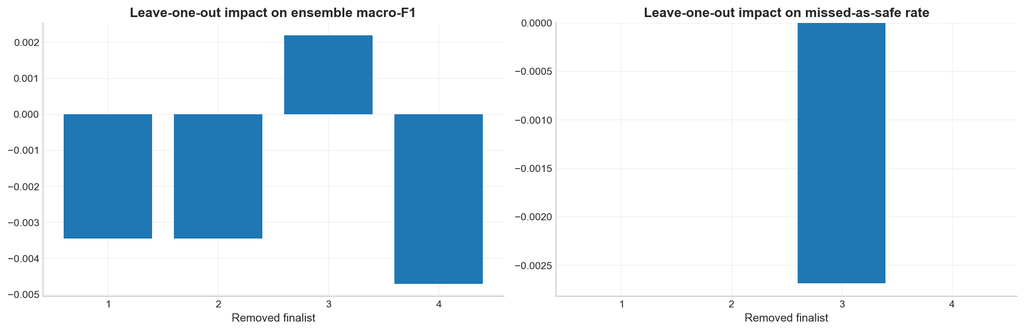

**Graph note**

This leave-one-out bar chart asks how much each finalist really contributes to the full ensemble.

How to read it: More negative macro-F1 change when a member is removed means that member adds more useful signal. Missed-as-safe deltas show whether the same member matters specifically for safety-critical behavior.

A near-zero change suggests redundancy rather than a useless model in isolation.

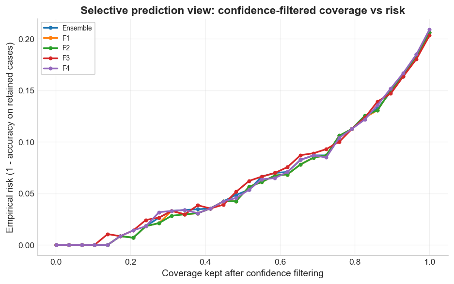

**Graph note**

This plot reuses the saved extra-audit per-example table to show how quickly risk falls as each model keeps only its highest-confidence cases.

How to read it: Lower curves are better. If one curve stays lower at the same coverage, that model's confidence ranking is more useful for selective prediction or review-based deployment.

This is a confidence-ordering diagnostic, not a replacement for the fixed-threshold operating-point analysis below.

[output not shown]

```python
base_meta = load_calibration_predictions(finalists_payload["finalists"][0]["members"][0]["run_name"], split="test").copy()
base_meta["target"] = ensemble_targets_test
base_meta["target_name"] = base_meta["target"].map(dict(enumerate(class_labels)))
for rank, probs in sorted(finalist_prob_map_test.items()):
    base_meta[f"f{rank}_pred"] = probs.argmax(axis=1)
    base_meta[f"f{rank}_conf"] = probs.max(axis=1)
    base_meta[f"f{rank}_p_unsafe"] = p_unsafe_from_probs(probs)
base_meta["ensemble_pred"] = ensemble_probs_test.argmax(axis=1)
base_meta["ensemble_conf"] = ensemble_probs_test.max(axis=1)
base_meta["ensemble_p_unsafe"] = p_unsafe_from_probs(ensemble_probs_test)

best_single_rank = int(single_model_df.sort_values(["macro_f1", "unsafe_macro_f1", "missed_as_safe_rate"], ascending=[False, False, True]).iloc[0]["finalist_rank"])
best_single_macro = float(single_model_df["macro_f1"].max())
base_meta["best_single_rank"] = best_single_rank
base_meta["best_single_pred"] = base_meta[f"f{best_single_rank}_pred"]
base_meta["best_single_conf"] = base_meta[f"f{best_single_rank}_conf"]
base_meta["best_single_p_unsafe"] = base_meta[f"f{best_single_rank}_p_unsafe"]
base_meta["ensemble_pred_name"] = base_meta["ensemble_pred"].map(dict(enumerate(class_labels)))
base_meta["best_single_pred_name"] = base_meta["best_single_pred"].map(dict(enumerate(class_labels)))

fix_examples_df = audit_fix_harm_df[audit_fix_harm_df["case_type"] == "ensemble_fix"].copy().head(5)
harm_examples_df = audit_fix_harm_df[audit_fix_harm_df["case_type"] == "ensemble_harm"].copy().head(5)

display(Markdown("**Representative cases where the ensemble fixes the strongest single finalist**"))
display(fix_examples_df[["id", "target_name", "best_single_pred_name", "ensemble_pred_name", "combined_category", "reduced_unsafe_class", "best_single_conf", "ensemble_conf", "best_single_p_unsafe", "ensemble_p_unsafe", "n_unique_finalist_preds"]])
display(Markdown("**Representative cases where the ensemble harms a correct strongest single finalist**"))
display(harm_examples_df[["id", "target_name", "best_single_pred_name", "ensemble_pred_name", "combined_category", "reduced_unsafe_class", "best_single_conf", "ensemble_conf", "best_single_p_unsafe", "ensemble_p_unsafe", "n_unique_finalist_preds"]])

coverage_rows = []
for label in [f"F{rank}" for rank in sorted(finalist_prob_map_test)] + ["Ensemble"]:
    prefix = label.lower() if label != "Ensemble" else "ensemble"
    conf_col = f"{prefix}_conf"
    correct_col = f"{prefix}_correct"
    sub = audit_prediction_df[[conf_col, correct_col]].dropna().sort_values(conf_col, ascending=False).reset_index(drop=True)
    if sub.empty:
        continue
    keep_points = np.unique(np.linspace(1, len(sub), num=min(30, len(sub)), dtype=int))
    for keep in keep_points:
        kept = sub.iloc[:keep]
        coverage_rows.append(
            {
                "model": label,
                "coverage": keep / len(sub),
                "risk": 1.0 - kept[correct_col].mean(),
            }
        )
coverage_df = pd.DataFrame(coverage_rows)

fig, axes = plt.subplots(1, 2, figsize=(14, 4.6))
axes[0].bar(loo_eval_df["removed_finalist"].astype(str), loo_eval_df["delta_macro_vs_full"])
axes[0].set_title("Leave-one-out impact on ensemble macro-F1")
axes[0].set_xlabel("Removed finalist")
axes[1].bar(loo_eval_df["removed_finalist"].astype(str), loo_eval_df["delta_missed_safe_vs_full"])
axes[1].set_title("Leave-one-out impact on missed-as-safe rate")
axes[1].set_xlabel("Removed finalist")
fig.tight_layout()
plt.show()
plt.close(fig)
display_note(
    title="Graph note",
    purpose="This leave-one-out bar chart asks how much each finalist really contributes to the full ensemble.",
    how_to_read="More negative macro-F1 change when a member is removed means that member adds more useful signal. Missed-as-safe deltas show whether the same member matters specifically for safety-critical behavior.",
    caveat="A near-zero change suggests redundancy rather than a useless model in isolation."
)

fig, ax = plt.subplots(figsize=(7.6, 4.8))
for model, sub in coverage_df.groupby("model"):
    ax.plot(sub["coverage"], sub["risk"], marker="o", markersize=3.6, linewidth=2, label=model)
ax.set_title("Selective prediction view: confidence-filtered coverage vs risk")
ax.set_xlabel("Coverage kept after confidence filtering")
ax.set_ylabel("Empirical risk (1 - accuracy on retained cases)")
ax.legend(fontsize=8)
fig.tight_layout()
plt.show()
plt.close(fig)
display_note(
    title="Graph note",
    purpose="This plot reuses the saved extra-audit per-example table to show how quickly risk falls as each model keeps only its highest-confidence cases.",
    how_to_read="Lower curves are better. If one curve stays lower at the same coverage, that model's confidence ranking is more useful for selective prediction or review-based deployment.",
    caveat="This is a confidence-ordering diagnostic, not a replacement for the fixed-threshold operating-point analysis below."
)
display(
    Markdown(
        f'''
        **Finding.** The ensemble needs to be interpreted member by member, not assumed to be better by default. The leave-one-out table shows which finalists add real complementary signal,
        while the overlap table exposes near-duplicate behavior. The most redundant-looking pair here is `F{int(most_redundant_pair["a"])}` and `F{int(most_redundant_pair["b"])}`,
        with disagreement {most_redundant_pair["pred_disagreement_count"]}/{int(most_redundant_pair["n_samples"])} = {most_redundant_pair["pred_disagreement_rate"]:.4f},
        shared-error rate {most_redundant_pair["shared_error_rate"]:.4f}, and shared unsafe-to-safe rate {most_redundant_pair["shared_unsafe_to_safe_rate"]:.4f}. The leave-one-out test says `F{int(most_helpful_removal["removed_finalist"])}` contributes the most to the full ensemble's macro-F1,
        because removing it changes macro-F1 by {most_helpful_removal["delta_macro_vs_full"]:+.4f}. Overall, the ensemble's small macro-F1 change relative to the best single finalist looks like {complementarity_text}:
        there is some real error correction in the fix cases, but the overlap structure shows that a chunk of the ensemble is still redundant.
        '''
    )
)
```

### Calibration Audit

Member-level temperature scaling should be judged mainly on reliability metrics, not on whether it rewrites the selection story. This section checks whether calibration materially improves ECE/Brier and whether it meaningfully changes argmax behavior.

|  | finalist_rank | seed | split | flat_temperature | macro_uncal | macro_cal | macro_delta | ece_uncal | ece_cal | ece_delta | brier_uncal | brier_cal | brier_delta |
| --- | --- | --- | --- | --- | --- | --- | --- | --- | --- | --- | --- | --- | --- |
| 0 | 1 | 45 | val | 1.188391 | 0.740217 | 0.740217 | 0.0 | 0.055071 | 0.040744 | -0.014327 | 0.283517 | 0.281640 | -0.001876 |
| 1 | 1 | 45 | test | 1.188391 | 0.702870 | 0.702870 | 0.0 | 0.057538 | 0.045001 | -0.012537 | 0.292601 | 0.290040 | -0.002562 |
| 2 | 1 | 46 | val | 1.164644 | 0.731037 | 0.731037 | 0.0 | 0.047354 | 0.043178 | -0.004177 | 0.277098 | 0.275544 | -0.001554 |
| 3 | 1 | 46 | test | 1.164644 | 0.714596 | 0.714596 | 0.0 | 0.048183 | 0.026543 | -0.021640 | 0.282420 | 0.280844 | -0.001577 |
| 4 | 1 | 47 | val | 1.161716 | 0.747145 | 0.747145 | 0.0 | 0.051222 | 0.041285 | -0.009938 | 0.272093 | 0.271219 | -0.000874 |
| 5 | 1 | 47 | test | 1.161716 | 0.717082 | 0.717082 | 0.0 | 0.042982 | 0.029073 | -0.013909 | 0.281476 | 0.279780 | -0.001696 |
| 6 | 2 | 45 | val | 1.188162 | 0.740217 | 0.740217 | 0.0 | 0.055070 | 0.040752 | -0.014318 | 0.283510 | 0.281637 | -0.001873 |
| 7 | 2 | 45 | test | 1.188162 | 0.702870 | 0.702870 | 0.0 | 0.057545 | 0.041496 | -0.016050 | 0.292623 | 0.290059 | -0.002564 |
| 8 | 2 | 46 | val | 1.164301 | 0.731037 | 0.731037 | 0.0 | 0.047338 | 0.043198 | -0.004139 | 0.277121 | 0.275567 | -0.001554 |
| 9 | 2 | 46 | test | 1.164301 | 0.714596 | 0.714596 | 0.0 | 0.049736 | 0.026559 | -0.023177 | 0.282432 | 0.280858 | -0.001575 |
| 10 | 2 | 47 | val | 1.162318 | 0.747145 | 0.747145 | 0.0 | 0.052780 | 0.041202 | -0.011578 | 0.272105 | 0.271233 | -0.000873 |
| 11 | 2 | 47 | test | 1.162318 | 0.717082 | 0.717082 | 0.0 | 0.042941 | 0.027714 | -0.015227 | 0.281510 | 0.279814 | -0.001696 |

**Average calibration deltas by finalist and split**

|  | finalist_rank | split | temp_mean | macro_delta_mean | ece_delta_mean | brier_delta_mean |
| --- | --- | --- | --- | --- | --- | --- |
| 0 | 1 | test | 1.171583 | 0.0 | -0.016029 | -0.001945 |
| 1 | 1 | val | 1.171583 | 0.0 | -0.009480 | -0.001435 |
| 2 | 2 | test | 1.171594 | 0.0 | -0.018151 | -0.001945 |
| 3 | 2 | val | 1.171594 | 0.0 | -0.010012 | -0.001433 |
| 4 | 3 | test | 1.046314 | 0.0 | -0.003025 | -0.000289 |
| 5 | 3 | val | 1.046314 | 0.0 | -0.001350 | 0.000034 |
| 6 | 4 | test | 1.171527 | 0.0 | -0.007984 | -0.002031 |
| 7 | 4 | val | 1.171527 | 0.0 | -0.013614 | -0.001460 |

**Explicit ensemble-level calibration before/after**

|  | model | mode | macro_f1 | weighted_f1 | ece | brier | unsafe_macro_f1 | missed_as_safe_rate |
| --- | --- | --- | --- | --- | --- | --- | --- | --- |
| 0 | ensemble_all | uncalibrated | 0.706373 | 0.797752 | 0.046194 | 0.283733 | 0.718669 | 0.056452 |
| 1 | ensemble_all | calibrated | 0.706373 | 0.797752 | 0.031393 | 0.282750 | 0.718669 | 0.056452 |

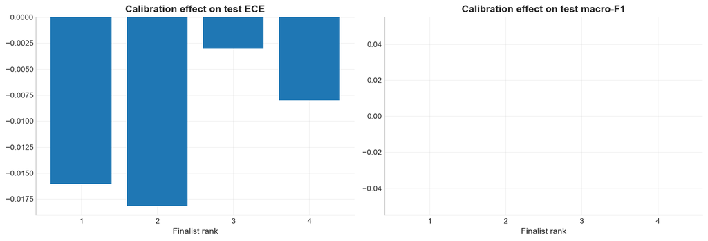

**Graph note**

These bars summarize how calibration changes reliability and macro-F1 on the test split.

How to read it: More negative ECE deltas are better because they mean improved calibration. Macro-F1 deltas close to zero mean calibration improved confidence quality without rewriting the classification ranking.

The reliability diagrams shown immediately after this are the more interpretable view of the same story.

**Reliability diagrams: strongest finalist F3**

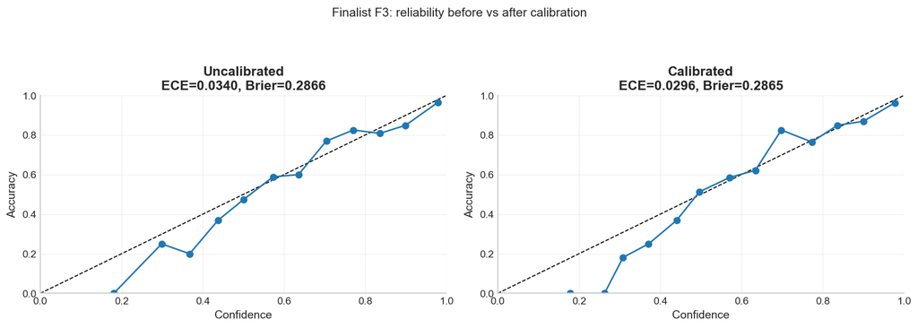

**Graph note**

This reliability pair compares confidence quality before and after temperature scaling on the same model or ensemble.

How to read it: The diagonal is perfect calibration. Curves closer to the diagonal mean the reported confidence better matches observed accuracy. The ECE and Brier values in each panel summarize the same calibration story numerically.

Calibration is not meant to improve the selection metric much here; it is mainly meant to make confidence and threshold-based decisions more trustworthy.

**Reliability diagrams: representative distinct finalist F1**

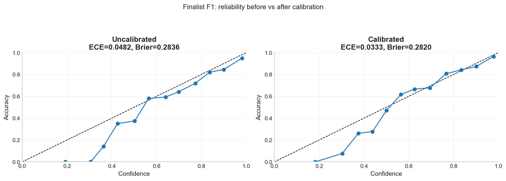

**Graph note**

This reliability pair compares confidence quality before and after temperature scaling on the same model or ensemble.

How to read it: The diagonal is perfect calibration. Curves closer to the diagonal mean the reported confidence better matches observed accuracy. The ECE and Brier values in each panel summarize the same calibration story numerically.

Calibration is not meant to improve the selection metric much here; it is mainly meant to make confidence and threshold-based decisions more trustworthy.

**Reliability diagrams: full ensemble**

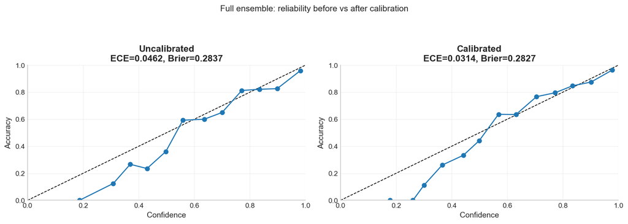

**Graph note**

This reliability pair compares confidence quality before and after temperature scaling on the same model or ensemble.

How to read it: The diagonal is perfect calibration. Curves closer to the diagonal mean the reported confidence better matches observed accuracy. The ECE and Brier values in each panel summarize the same calibration story numerically.

Calibration is not meant to improve the selection metric much here; it is mainly meant to make confidence and threshold-based decisions more trustworthy.

```
    **Finding.** The reliability diagrams make the calibration story more concrete than the delta tables alone. For the strongest finalist F3,
    ECE moves from 0.0340 to 0.0296; for the representative distinct finalist F1,
    it moves from 0.0482 to 0.0333; and for the full ensemble it moves from 0.0462 to 0.0314
    while macro-F1 stays essentially unchanged at 0.7064. That pattern supports the intended interpretation:
    calibration materially improves reliability, but mostly leaves argmax behavior intact.
```

```python
calibration_rows = []
for finalist in finalists_payload["finalists"]:
    for member in finalist["members"]:
        cal = load_calibration_summary(member["run_name"])
        flat_temp = float(cal["temperatures"]["flat_temperature"])
        for split in ["val", "test"]:
            un = cal["splits"][split]["uncalibrated"]
            ca = cal["splits"][split]["calibrated"]
            calibration_rows.append(
                {
                    "finalist_rank": int(finalist["finalist_rank"]),
                    "seed": int(member["seed"]),
                    "split": split,
                    "flat_temperature": flat_temp,
                    "macro_uncal": float(un["flat9_metrics"]["macro_f1"]),
                    "macro_cal": float(ca["flat9_metrics"]["macro_f1"]),
                    "macro_delta": float(ca["flat9_metrics"]["macro_f1"] - un["flat9_metrics"]["macro_f1"]),
                    "ece_uncal": float(un["flat9_reliability"]["ece"]),
                    "ece_cal": float(ca["flat9_reliability"]["ece"]),
                    "ece_delta": float(ca["flat9_reliability"]["ece"] - un["flat9_reliability"]["ece"]),
                    "brier_uncal": float(un["flat9_reliability"]["brier"]),
                    "brier_cal": float(ca["flat9_reliability"]["brier"]),
                    "brier_delta": float(ca["flat9_reliability"]["brier"] - un["flat9_reliability"]["brier"]),
                }
            )
calibration_df = pd.DataFrame(calibration_rows)
display(calibration_df.head(12))

calibration_summary_df = (
    calibration_df.groupby(["finalist_rank", "split"])
    .agg(
        temp_mean=("flat_temperature", "mean"),
        macro_delta_mean=("macro_delta", "mean"),
        ece_delta_mean=("ece_delta", "mean"),
        brier_delta_mean=("brier_delta", "mean"),
    )
    .reset_index()
)
display(Markdown("**Average calibration deltas by finalist and split**"))
display(calibration_summary_df)

finalist_prob_map_test_uncal, targets_test_uncal, _ = load_finalist_probabilities(split="test", prob_key="probs_uncalibrated")
ensemble_probs_test_uncal, ensemble_targets_test_uncal, _, _ = full_ensemble_probs(split="test", prob_key="probs_uncalibrated")

ensemble_calibration_df = pd.DataFrame(
    [
        {
            "model": "ensemble_all",
            "mode": "uncalibrated",
            **{k: v for k, v in metric_dict_from_probs(ensemble_probs_test_uncal, ensemble_targets_test_uncal).items() if k in ["macro_f1", "weighted_f1", "ece", "brier", "unsafe_macro_f1", "missed_as_safe_rate"]},
        },
        {
            "model": "ensemble_all",
            "mode": "calibrated",
            **{k: v for k, v in metric_dict_from_probs(ensemble_probs_test, ensemble_targets_test).items() if k in ["macro_f1", "weighted_f1", "ece", "brier", "unsafe_macro_f1", "missed_as_safe_rate"]},
        },
    ]
)
display(Markdown("**Explicit ensemble-level calibration before/after**"))
display(ensemble_calibration_df)

fig, axes = plt.subplots(1, 2, figsize=(13, 4.5))
plot_df = calibration_summary_df[calibration_summary_df["split"] == "test"].copy()
axes[0].bar(plot_df["finalist_rank"].astype(str), plot_df["ece_delta_mean"])
axes[0].set_title("Calibration effect on test ECE")
axes[1].bar(plot_df["finalist_rank"].astype(str), plot_df["macro_delta_mean"])
axes[1].set_title("Calibration effect on test macro-F1")
for ax in axes:
    ax.set_xlabel("Finalist rank")
fig.tight_layout()
plt.show()
plt.close(fig)
display_note(
    title="Graph note",
    purpose="These bars summarize how calibration changes reliability and macro-F1 on the test split.",
    how_to_read="More negative ECE deltas are better because they mean improved calibration. Macro-F1 deltas close to zero mean calibration improved confidence quality without rewriting the classification ranking.",
    caveat="The reliability diagrams shown immediately after this are the more interpretable view of the same story."
)

strongest_rank = int(single_model_df.sort_values(["macro_f1", "unsafe_macro_f1", "missed_as_safe_rate"], ascending=[False, False, True]).iloc[0]["finalist_rank"])
representative_rank = int(overlap_df.loc[(overlap_df["a"] == strongest_rank) | (overlap_df["b"] == strongest_rank)].assign(other=lambda df_: np.where(df_["a"] == strongest_rank, df_["b"], df_["a"])).sort_values("pred_disagreement_rate", ascending=False).iloc[0]["other"])

display(Markdown(f"**Reliability diagrams: strongest finalist F{strongest_rank}**"))
strongest_uncal_metrics, strongest_cal_metrics = plot_reliability_diagram_pair(
    finalist_prob_map_test_uncal[strongest_rank],
    finalist_prob_map_test[strongest_rank],
    ensemble_targets_test,
    title=f"Finalist F{strongest_rank}: reliability before vs after calibration",
)

display(Markdown(f"**Reliability diagrams: representative distinct finalist F{representative_rank}**"))
rep_uncal_metrics, rep_cal_metrics = plot_reliability_diagram_pair(
    finalist_prob_map_test_uncal[representative_rank],
    finalist_prob_map_test[representative_rank],
    ensemble_targets_test,
    title=f"Finalist F{representative_rank}: reliability before vs after calibration",
)

display(Markdown("**Reliability diagrams: full ensemble**"))
ens_uncal_metrics, ens_cal_metrics = plot_reliability_diagram_pair(
    ensemble_probs_test_uncal,
    ensemble_probs_test,
    ensemble_targets_test,
    title="Full ensemble: reliability before vs after calibration",
)

display(
    Markdown(
        f'''
        **Finding.** The reliability diagrams make the calibration story more concrete than the delta tables alone. For the strongest finalist F{strongest_rank},
        ECE moves from {strongest_uncal_metrics["ece"]:.4f} to {strongest_cal_metrics["ece"]:.4f}; for the representative distinct finalist F{representative_rank},
        it moves from {rep_uncal_metrics["ece"]:.4f} to {rep_cal_metrics["ece"]:.4f}; and for the full ensemble it moves from {ens_uncal_metrics["ece"]:.4f} to {ens_cal_metrics["ece"]:.4f}
        while macro-F1 stays essentially unchanged at {ensemble_calibration_df.loc[ensemble_calibration_df["mode"] == "calibrated", "macro_f1"].iloc[0]:.4f}. That pattern supports the intended interpretation:
        calibration materially improves reliability, but mostly leaves argmax behavior intact.
        '''
    )
)
```

### Threshold / Operating-Point Analysis

This section is deployment-oriented and separate from the model-selection logic. Throughout the notebook, `p(unsafe)` is defined exactly as `1 - p(Safe)`, which is equivalent to the sum of the calibrated class probabilities over unsafe classes `1..8`.

|  | threshold | unsafe_precision | unsafe_recall | safe_false_positive_rate | missed_as_safe_rate | split | model |
| --- | --- | --- | --- | --- | --- | --- | --- |
| 0 | 0.25 | 0.841743 | 0.986559 | 0.221154 | 0.013441 | test | ensemble_all |
| 1 | 0.75 | 0.934959 | 0.927419 | 0.076923 | 0.072581 | test | ensemble_all |
| 2 | 0.25 | 0.843678 | 0.986559 | 0.217949 | 0.013441 | test | finalist_1 |
| 3 | 0.75 | 0.937158 | 0.922043 | 0.073718 | 0.077957 | test | finalist_1 |
| 4 | 0.25 | 0.843678 | 0.986559 | 0.217949 | 0.013441 | test | finalist_2 |
| 5 | 0.75 | 0.937158 | 0.922043 | 0.073718 | 0.077957 | test | finalist_2 |
| 6 | 0.25 | 0.832200 | 0.986559 | 0.237179 | 0.013441 | test | finalist_3 |
| 7 | 0.75 | 0.925333 | 0.932796 | 0.089744 | 0.067204 | test | finalist_3 |
| 8 | 0.25 | 0.841743 | 0.986559 | 0.221154 | 0.013441 | test | finalist_4 |
| 9 | 0.75 | 0.934959 | 0.927419 | 0.076923 | 0.072581 | test | finalist_4 |
| 10 | 0.25 | 0.833713 | 0.986523 | 0.233974 | 0.013477 | val | ensemble_all |
| 11 | 0.75 | 0.951351 | 0.948787 | 0.057692 | 0.051213 | val | ensemble_all |
| 12 | 0.25 | 0.835616 | 0.986523 | 0.230769 | 0.013477 | val | finalist_1 |
| 13 | 0.75 | 0.951220 | 0.946092 | 0.057692 | 0.053908 | val | finalist_1 |
| 14 | 0.25 | 0.835616 | 0.986523 | 0.230769 | 0.013477 | val | finalist_2 |
| 15 | 0.75 | 0.951220 | 0.946092 | 0.057692 | 0.053908 | val | finalist_2 |
| 16 | 0.25 | 0.826966 | 0.991914 | 0.246795 | 0.008086 | val | finalist_3 |
| 17 | 0.75 | 0.946524 | 0.954178 | 0.064103 | 0.045822 | val | finalist_3 |
| 18 | 0.25 | 0.833713 | 0.986523 | 0.233974 | 0.013477 | val | finalist_4 |
| 19 | 0.75 | 0.951351 | 0.948787 | 0.057692 | 0.051213 | val | finalist_4 |

**All finalists plus ensemble at threshold 0.50**

|  | threshold | unsafe_precision | unsafe_recall | safe_false_positive_rate | missed_as_safe_rate | split | model |
| --- | --- | --- | --- | --- | --- | --- | --- |
| 0 | 0.5 | 0.890819 | 0.965054 | 0.141026 | 0.034946 | test | finalist_3 |
| 1 | 0.5 | 0.897243 | 0.962366 | 0.131410 | 0.037634 | test | ensemble_all |
| 2 | 0.5 | 0.894472 | 0.956989 | 0.134615 | 0.043011 | test | finalist_4 |
| 3 | 0.5 | 0.896465 | 0.954301 | 0.131410 | 0.045699 | test | finalist_1 |
| 4 | 0.5 | 0.896465 | 0.954301 | 0.131410 | 0.045699 | test | finalist_2 |
| 5 | 0.5 | 0.889706 | 0.978437 | 0.144231 | 0.021563 | val | finalist_3 |
| 6 | 0.5 | 0.893564 | 0.973046 | 0.137821 | 0.026954 | val | ensemble_all |
| 7 | 0.5 | 0.900000 | 0.970350 | 0.128205 | 0.029650 | val | finalist_4 |
| 8 | 0.5 | 0.893300 | 0.970350 | 0.137821 | 0.029650 | val | finalist_1 |
| 9 | 0.5 | 0.893300 | 0.970350 | 0.137821 | 0.029650 | val | finalist_2 |

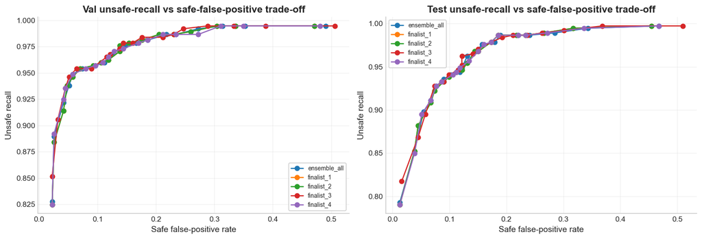

**Graph note**

These operating curves show deployment trade-offs after converting multiclass probabilities into `p(unsafe)`.

How to read it: Moving upward increases unsafe recall, while moving right increases false alarms on safe samples. A model farther up and left is preferable at a given operating point, but different applications may prefer different trade-offs.

This section is deployment-oriented only and is intentionally separate from the search-stage selection rule.

```
    **Finding.** The threshold sweep now includes all four finalists plus the full ensemble, so no finalist is silently omitted. At the default 0.50 threshold on test,
    the best unsafe-recall operating point among the finalists comes from `finalist_3`,
    while the strongest precision-retaining operating point comes from `ensemble_all`.
    The ensemble sits inside that trade-off rather than dominating it outright. The threshold sweep shows deployment trade-offs that are invisible at the default argmax operating point.
    Because `p(unsafe)` is defined consistently as `1 - p(Safe)` throughout, the curves are directly comparable across finalists and the full ensemble.
    The goal here is not to re-rank models, but to show how much unsafe recall can be bought for a given safe false-positive budget and how calibration-informed thresholding changes missed-as-safe behavior in practice.
```

```python
threshold_records = []
threshold_focus_rows = []

best_macro_rank = int(single_model_df.sort_values(["macro_f1", "unsafe_macro_f1"], ascending=[False, False]).iloc[0]["finalist_rank"])
best_safety_rank = int(single_model_df.sort_values(["missed_as_safe_rate", "unsafe_macro_f1"], ascending=[True, False]).iloc[0]["finalist_rank"])

threshold_focus = [("ensemble_all", None)] + [(f"finalist_{rank}", rank) for rank in sorted(finalist_prob_map_test)]

for split in ["val", "test"]:
    ensemble_probs_split, targets_split, finalist_prob_map_split, _ = full_ensemble_probs(split=split)
    for label, rank in threshold_focus:
        probs = ensemble_probs_split if rank is None else finalist_prob_map_split[rank]
        sweep_df = threshold_sweep(probs, targets_split)
        sweep_df["split"] = split
        sweep_df["model"] = label
        threshold_records.append(sweep_df)
        focus = sweep_df[sweep_df["threshold"].isin([0.25, 0.5, 0.75])].copy()
        threshold_focus_rows.append(focus)

threshold_results_df = pd.concat(threshold_records, ignore_index=True)
threshold_focus_df = pd.concat(threshold_focus_rows, ignore_index=True)
display(threshold_focus_df.sort_values(["split", "model", "threshold"]).reset_index(drop=True))

threshold_at_half_df = threshold_results_df[np.isclose(threshold_results_df["threshold"], 0.5)].sort_values(["split", "unsafe_recall", "unsafe_precision"], ascending=[True, False, False]).reset_index(drop=True)
display(Markdown("**All finalists plus ensemble at threshold 0.50**"))
display(threshold_at_half_df)

fig, axes = plt.subplots(1, 2, figsize=(13, 4.5))
for (split, model), sub in threshold_results_df.groupby(["split", "model"]):
    ax = axes[0] if split == "val" else axes[1]
    ax.plot(sub["safe_false_positive_rate"], sub["unsafe_recall"], marker="o", label=model)
    ax.set_title(f"{split.title()} unsafe-recall vs safe-false-positive trade-off")
    ax.set_xlabel("Safe false-positive rate")
    ax.set_ylabel("Unsafe recall")
    ax.legend(fontsize=8)
fig.tight_layout()
plt.show()
plt.close(fig)
display_note(
    title="Graph note",
    purpose="These operating curves show deployment trade-offs after converting multiclass probabilities into `p(unsafe)`.",
    how_to_read="Moving upward increases unsafe recall, while moving right increases false alarms on safe samples. A model farther up and left is preferable at a given operating point, but different applications may prefer different trade-offs.",
    caveat="This section is deployment-oriented only and is intentionally separate from the search-stage selection rule."
)

display(
    Markdown(
        f'''
        **Finding.** The threshold sweep now includes all four finalists plus the full ensemble, so no finalist is silently omitted. At the default 0.50 threshold on test,
        the best unsafe-recall operating point among the finalists comes from `{threshold_at_half_df[threshold_at_half_df["split"] == "test"].sort_values("unsafe_recall", ascending=False).iloc[0]["model"]}`,
        while the strongest precision-retaining operating point comes from `{threshold_at_half_df[threshold_at_half_df["split"] == "test"].sort_values("unsafe_precision", ascending=False).iloc[0]["model"]}`.
        The ensemble sits inside that trade-off rather than dominating it outright. The threshold sweep shows deployment trade-offs that are invisible at the default argmax operating point.
        Because `p(unsafe)` is defined consistently as `1 - p(Safe)` throughout, the curves are directly comparable across finalists and the full ensemble.
        The goal here is not to re-rank models, but to show how much unsafe recall can be bought for a given safe false-positive budget and how calibration-informed thresholding changes missed-as-safe behavior in practice.
        '''
    )
)
```

### Modality Reliance Audit

The extra audit script also reran the shortlisted models under simple modality ablations. By zeroing either the text or image embedding before the fusion head, we can see whether the finalists and the ensemble really use multimodal signal, or whether one modality is carrying most of the behavior.

|  | model | type | mode | macro_f1 | weighted_f1 | accuracy | unsafe_macro_f1 | unsafe_recall | missed_as_safe_rate | ece | brier |
| --- | --- | --- | --- | --- | --- | --- | --- | --- | --- | --- | --- |
| 0 | Ensemble | ensemble | full | 0.706373 | 0.797752 | 0.793860 | 0.718669 | 0.943548 | 0.056452 | 0.046194 | 0.283733 |
| 1 | Ensemble | ensemble | image_only | 0.490087 | 0.621958 | 0.608187 | 0.513138 | 0.849462 | 0.150538 | 0.129458 | 0.566197 |
| 2 | Ensemble | ensemble | text_only | 0.672697 | 0.779059 | 0.782164 | 0.667679 | 0.879032 | 0.120968 | 0.043177 | 0.313717 |
| 3 | F1 | finalist | full | 0.705920 | 0.797754 | 0.793860 | 0.718047 | 0.943548 | 0.056452 | 0.048206 | 0.283629 |
| 4 | F1 | finalist | image_only | 0.484260 | 0.619887 | 0.608187 | 0.504691 | 0.833333 | 0.166667 | 0.113736 | 0.561862 |
| 5 | F1 | finalist | text_only | 0.674618 | 0.781712 | 0.785088 | 0.668673 | 0.879032 | 0.120968 | 0.042203 | 0.312310 |
| 6 | F2 | finalist | full | 0.705920 | 0.797754 | 0.793860 | 0.718047 | 0.943548 | 0.056452 | 0.048191 | 0.283652 |
| 7 | F2 | finalist | image_only | 0.484260 | 0.619887 | 0.608187 | 0.504691 | 0.833333 | 0.166667 | 0.113781 | 0.561872 |
| 8 | F2 | finalist | text_only | 0.674618 | 0.781712 | 0.785088 | 0.668673 | 0.879032 | 0.120968 | 0.042212 | 0.312325 |
| 9 | F3 | finalist | full | 0.708331 | 0.801598 | 0.796784 | 0.717664 | 0.956989 | 0.043011 | 0.033997 | 0.286644 |
| 10 | F3 | finalist | image_only | 0.499817 | 0.628463 | 0.612573 | 0.527002 | 0.862903 | 0.137097 | 0.167847 | 0.579463 |
| 11 | F3 | finalist | text_only | 0.676597 | 0.778517 | 0.777778 | 0.680690 | 0.895161 | 0.104839 | 0.062403 | 0.321503 |
| 12 | F4 | finalist | full | 0.702938 | 0.795181 | 0.790936 | 0.716546 | 0.943548 | 0.056452 | 0.048889 | 0.284479 |
| 13 | F4 | finalist | image_only | 0.486614 | 0.616909 | 0.603801 | 0.507849 | 0.833333 | 0.166667 | 0.109805 | 0.565857 |
| 14 | F4 | finalist | text_only | 0.679393 | 0.782761 | 0.786550 | 0.674747 | 0.873656 | 0.126344 | 0.047507 | 0.312723 |

**Delta from the full model for each ablated mode**

|  | model | type | mode | macro_f1 | weighted_f1 | accuracy | unsafe_macro_f1 | unsafe_recall | missed_as_safe_rate | ece | brier | full_macro_f1 | full_unsafe_recall | full_missed_as_safe_rate | macro_drop_vs_full | unsafe_recall_drop_vs_full | missed_safe_delta_vs_full |
| --- | --- | --- | --- | --- | --- | --- | --- | --- | --- | --- | --- | --- | --- | --- | --- | --- | --- |
| 0 | Ensemble | ensemble | full | 0.706373 | 0.797752 | 0.793860 | 0.718669 | 0.943548 | 0.056452 | 0.046194 | 0.283733 | 0.706373 | 0.943548 | 0.056452 | 0.000000 | 0.000000 | 0.000000 |
| 1 | Ensemble | ensemble | image_only | 0.490087 | 0.621958 | 0.608187 | 0.513138 | 0.849462 | 0.150538 | 0.129458 | 0.566197 | 0.706373 | 0.943548 | 0.056452 | -0.216286 | -0.094086 | 0.094086 |
| 2 | Ensemble | ensemble | text_only | 0.672697 | 0.779059 | 0.782164 | 0.667679 | 0.879032 | 0.120968 | 0.043177 | 0.313717 | 0.706373 | 0.943548 | 0.056452 | -0.033675 | -0.064516 | 0.064516 |
| 3 | F1 | finalist | full | 0.705920 | 0.797754 | 0.793860 | 0.718047 | 0.943548 | 0.056452 | 0.048206 | 0.283629 | 0.705920 | 0.943548 | 0.056452 | 0.000000 | 0.000000 | 0.000000 |
| 4 | F1 | finalist | image_only | 0.484260 | 0.619887 | 0.608187 | 0.504691 | 0.833333 | 0.166667 | 0.113736 | 0.561862 | 0.705920 | 0.943548 | 0.056452 | -0.221660 | -0.110215 | 0.110215 |
| 5 | F1 | finalist | text_only | 0.674618 | 0.781712 | 0.785088 | 0.668673 | 0.879032 | 0.120968 | 0.042203 | 0.312310 | 0.705920 | 0.943548 | 0.056452 | -0.031302 | -0.064516 | 0.064516 |
| 6 | F2 | finalist | full | 0.705920 | 0.797754 | 0.793860 | 0.718047 | 0.943548 | 0.056452 | 0.048191 | 0.283652 | 0.705920 | 0.943548 | 0.056452 | 0.000000 | 0.000000 | 0.000000 |
| 7 | F2 | finalist | image_only | 0.484260 | 0.619887 | 0.608187 | 0.504691 | 0.833333 | 0.166667 | 0.113781 | 0.561872 | 0.705920 | 0.943548 | 0.056452 | -0.221660 | -0.110215 | 0.110215 |
| 8 | F2 | finalist | text_only | 0.674618 | 0.781712 | 0.785088 | 0.668673 | 0.879032 | 0.120968 | 0.042212 | 0.312325 | 0.705920 | 0.943548 | 0.056452 | -0.031302 | -0.064516 | 0.064516 |
| 9 | F3 | finalist | full | 0.708331 | 0.801598 | 0.796784 | 0.717664 | 0.956989 | 0.043011 | 0.033997 | 0.286644 | 0.708331 | 0.956989 | 0.043011 | 0.000000 | 0.000000 | 0.000000 |
| 10 | F3 | finalist | image_only | 0.499817 | 0.628463 | 0.612573 | 0.527002 | 0.862903 | 0.137097 | 0.167847 | 0.579463 | 0.708331 | 0.956989 | 0.043011 | -0.208513 | -0.094086 | 0.094086 |
| 11 | F3 | finalist | text_only | 0.676597 | 0.778517 | 0.777778 | 0.680690 | 0.895161 | 0.104839 | 0.062403 | 0.321503 | 0.708331 | 0.956989 | 0.043011 | -0.031733 | -0.061828 | 0.061828 |
| 12 | F4 | finalist | full | 0.702938 | 0.795181 | 0.790936 | 0.716546 | 0.943548 | 0.056452 | 0.048889 | 0.284479 | 0.702938 | 0.943548 | 0.056452 | 0.000000 | 0.000000 | 0.000000 |
| 13 | F4 | finalist | image_only | 0.486614 | 0.616909 | 0.603801 | 0.507849 | 0.833333 | 0.166667 | 0.109805 | 0.565857 | 0.702938 | 0.943548 | 0.056452 | -0.216324 | -0.110215 | 0.110215 |
| 14 | F4 | finalist | text_only | 0.679393 | 0.782761 | 0.786550 | 0.674747 | 0.873656 | 0.126344 | 0.047507 | 0.312723 | 0.702938 | 0.943548 | 0.056452 | -0.023545 | -0.069892 | 0.069892 |

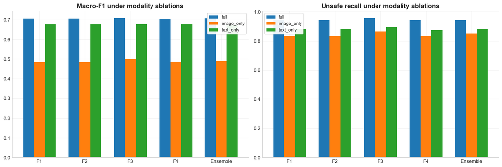

**Graph note**

These grouped bars compare the full model against image-only and text-only ablations for each finalist and the ensemble.

How to read it: Large drops from `full` to an ablated mode mean the removed modality was carrying useful signal. If both ablations hurt, the recipe is using both modalities meaningfully rather than just one.

These are zero-out ablations on the saved trained models; they are useful behavioral probes, but they do not retrain or recalibrate the ablated variants.

**Classes most damaged for Ensemble when one modality is removed**

|  | mode | class_name | support | full_per_class_f1 | delta_vs_full |
| --- | --- | --- | --- | --- | --- |
| 8 | image_only | Exploitation & Abuse | 19 | 0.615385 | -0.365385 |
| 5 | image_only | Sexual Content | 49 | 0.845361 | -0.337898 |
| 1 | image_only | Hate, Harassment & Discrimination | 38 | 0.613333 | -0.293889 |
| 6 | image_only | Conflict, Terrorism & Extremism | 31 | 0.684932 | -0.284932 |
| 7 | image_only | Platform Abuse, Fraud & Evasion | 31 | 0.593750 | -0.215372 |
| 0 | image_only | Safe | 312 | 0.908197 | -0.149343 |
| 4 | image_only | Violence, Weapons & Gore | 125 | 0.747826 | -0.131086 |
| 3 | image_only | Self-Harm & Suicide | 45 | 0.628571 | -0.122824 |
| 11 | text_only | Substance Abuse & Addictive Behavior | 34 | 0.720000 | -0.065455 |
| 17 | text_only | Exploitation & Abuse | 19 | 0.615385 | -0.059829 |

```
    **Finding.** The modality audit says the shortlisted models are not just leaning on one channel. The biggest macro-F1 drop among the saved ablations is
    `F1` in `image_only` mode (-0.2217 vs full),
    and the largest unsafe-recall drop is `F1` in `image_only` mode (-0.1102 vs full).
    The class-level table above shows where that loss concentrates for `Ensemble`, which makes the modality story operational rather than abstract.
```

```python
modality_df = audit_modality_summary_df.copy()
model_order = modality_df["model"].drop_duplicates().tolist()
mode_order = [mode for mode in ["full", "image_only", "text_only"] if mode in modality_df["mode"].unique().tolist()]
display(modality_df.sort_values(["model", "mode"]).reset_index(drop=True))

modality_delta_df = (
    modality_df.merge(
        modality_df[modality_df["mode"] == "full"][["model", "macro_f1", "unsafe_recall", "missed_as_safe_rate"]].rename(
            columns={
                "macro_f1": "full_macro_f1",
                "unsafe_recall": "full_unsafe_recall",
                "missed_as_safe_rate": "full_missed_as_safe_rate",
            }
        ),
        on="model",
        how="left",
    )
    .assign(
        macro_drop_vs_full=lambda df_: df_["macro_f1"] - df_["full_macro_f1"],
        unsafe_recall_drop_vs_full=lambda df_: df_["unsafe_recall"] - df_["full_unsafe_recall"],
        missed_safe_delta_vs_full=lambda df_: df_["missed_as_safe_rate"] - df_["full_missed_as_safe_rate"],
    )
)
display(Markdown("**Delta from the full model for each ablated mode**"))
display(modality_delta_df.sort_values(["model", "mode"]).reset_index(drop=True))

fig, axes = plt.subplots(1, 2, figsize=(14.2, 4.8))
xs = np.arange(len(model_order))
width = 0.24
offsets = np.linspace(-width, width, len(mode_order)) if len(mode_order) > 1 else np.array([0.0])
for idx, mode in enumerate(mode_order):
    sub = modality_df[modality_df["mode"] == mode].set_index("model").reindex(model_order)
    axes[0].bar(xs + offsets[idx], sub["macro_f1"], width=width, label=mode)
    axes[1].bar(xs + offsets[idx], sub["unsafe_recall"], width=width, label=mode)
axes[0].set_title("Macro-F1 under modality ablations")
axes[1].set_title("Unsafe recall under modality ablations")
for ax in axes:
    ax.set_xticks(xs, labels=model_order, rotation=0)
    ax.legend()
fig.tight_layout()
plt.show()
plt.close(fig)
display_note(
    title="Graph note",
    purpose="These grouped bars compare the full model against image-only and text-only ablations for each finalist and the ensemble.",
    how_to_read="Large drops from `full` to an ablated mode mean the removed modality was carrying useful signal. If both ablations hurt, the recipe is using both modalities meaningfully rather than just one.",
    caveat="These are zero-out ablations on the saved trained models; they are useful behavioral probes, but they do not retrain or recalibrate the ablated variants."
)

ensemble_model_name = modality_df.loc[modality_df["type"] == "ensemble", "model"].iloc[0] if (modality_df["type"] == "ensemble").any() else model_order[-1]
class_delta_rows = []
ensemble_class_df = audit_modality_by_class_df[audit_modality_by_class_df["model"] == ensemble_model_name].copy()
if not ensemble_class_df.empty and "full" in ensemble_class_df["mode"].unique():
    class_full_df = ensemble_class_df[ensemble_class_df["mode"] == "full"][["class_id", "class_name", "support", "per_class_f1"]].rename(columns={"per_class_f1": "full_per_class_f1"})
    for mode in [m for m in mode_order if m != "full"]:
        class_mode_df = ensemble_class_df[ensemble_class_df["mode"] == mode][["class_id", "class_name", "support", "per_class_f1"]].rename(columns={"per_class_f1": f"{mode}_per_class_f1"})
        merged = class_full_df.merge(class_mode_df, on=["class_id", "class_name", "support"], how="left")
        merged["mode"] = mode
        merged["delta_vs_full"] = merged[f"{mode}_per_class_f1"] - merged["full_per_class_f1"]
        class_delta_rows.append(merged)
class_delta_df = pd.concat(class_delta_rows, ignore_index=True) if class_delta_rows else pd.DataFrame()
if not class_delta_df.empty:
    display(Markdown(f"**Classes most damaged for {ensemble_model_name} when one modality is removed**"))
    display(class_delta_df.sort_values("delta_vs_full").head(10)[["mode", "class_name", "support", "full_per_class_f1", "delta_vs_full"]])

strongest_macro_mode = modality_delta_df[modality_delta_df["mode"] != "full"].sort_values("macro_drop_vs_full").iloc[0]
strongest_recall_mode = modality_delta_df[modality_delta_df["mode"] != "full"].sort_values("unsafe_recall_drop_vs_full").iloc[0]
display(
    Markdown(
        f'''
        **Finding.** The modality audit says the shortlisted models are not just leaning on one channel. The biggest macro-F1 drop among the saved ablations is
        `{strongest_macro_mode["model"]}` in `{strongest_macro_mode["mode"]}` mode ({strongest_macro_mode["macro_drop_vs_full"]:+.4f} vs full),
        and the largest unsafe-recall drop is `{strongest_recall_mode["model"]}` in `{strongest_recall_mode["mode"]}` mode ({strongest_recall_mode["unsafe_recall_drop_vs_full"]:+.4f} vs full).
        The class-level table above shows where that loss concentrates for `{ensemble_model_name}`, which makes the modality story operational rather than abstract.
        '''
    )
)
```

### Internal Head-Consistency Audit

The finalists use `flat_aux_hier`, so each model contains not only a flat 9-way head but also auxiliary binary and unsafe-subclass heads. This section asks whether internal disagreement among those heads is informative, especially for safety-critical misses.

|  | model | binary_disagreement_rate | unsafe_head_disagreement_rate_on_flat_unsafe | error_rate_when_binary_agree | error_rate_when_binary_disagree | unsafe_to_safe_rate_when_binary_disagree | alert_precision_flat_safe_aux_unsafe | error_gap_disagree_minus_agree |
| --- | --- | --- | --- | --- | --- | --- | --- | --- |
| 0 | F1 | 0.030702 | 0.987047 | 0.197587 | 0.476190 | 0.095238 | 0.500000 | 0.278604 |
| 1 | F2 | 0.030702 | 0.987047 | 0.197587 | 0.476190 | 0.095238 | 0.500000 | 0.278604 |
| 2 | F3 | 0.033626 | 0.951282 | 0.198185 | 0.347826 | 0.043478 | 0.166667 | 0.149642 |
| 3 | F4 | 0.033626 | 0.002584 | 0.196672 | 0.565217 | 0.086957 | 0.500000 | 0.368546 |

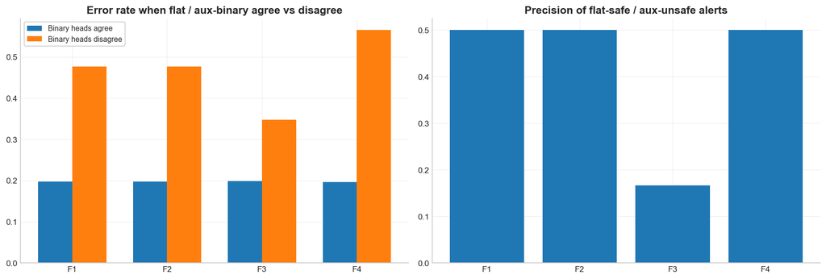

**Graph note**

These plots use the saved head-consistency audit to show whether internal head disagreement is a useful warning sign.

How to read it: If the `disagree` bar is much higher than the `agree` bar, internal disagreement is enriched for errors. Higher alert precision means the specific `flat predicts Safe but aux-binary leans Unsafe` pattern is often a real problem case.

This applies to the four finalists only; the top-level ensemble has no single auxiliary head to audit.

**Representative head-disagreement alert cases**

|  | model | id | target_name | flat_pred_name | flat_conf | flat_p_unsafe | aux_binary_prob_unsafe | correct | unsafe_to_safe |
| --- | --- | --- | --- | --- | --- | --- | --- | --- | --- |
| 4 | F2 | 1262 | Conflict, Terrorism & Extremism | Safe | 0.192309 | 0.807691 | 0.787141 | 0 | 1 |
| 0 | F1 | 1262 | Conflict, Terrorism & Extremism | Safe | 0.192436 | 0.807564 | 0.786960 | 0 | 1 |
| 14 | F4 | 1262 | Conflict, Terrorism & Extremism | Safe | 0.192494 | 0.807506 | 0.782133 | 0 | 1 |
| 9 | F3 | 2745 | Substance Abuse & Addictive Behavior | Safe | 0.355026 | 0.644973 | 0.689756 | 0 | 1 |
| 2 | F1 | 2745 | Substance Abuse & Addictive Behavior | Safe | 0.407349 | 0.592651 | 0.650504 | 0 | 1 |
| 6 | F2 | 2745 | Substance Abuse & Addictive Behavior | Safe | 0.407411 | 0.592589 | 0.650233 | 0 | 1 |
| 16 | F4 | 2745 | Substance Abuse & Addictive Behavior | Safe | 0.417109 | 0.582891 | 0.613161 | 0 | 1 |
| 8 | F3 | 775 | Safe | Safe | 0.307226 | 0.692774 | 0.717614 | 1 | 0 |

```
    **Finding.** Internal disagreement is not common, but it is much riskier than ordinary agreement. In the sharpest case, `F4` has
    error rate 0.1967 when the flat and auxiliary binary heads agree versus
    0.5652 when they disagree. The alert-case table above shows why this matters:
    some flat-safe predictions still carry high auxiliary unsafe probability, which makes internal disagreement a plausible review trigger.
```

```python
head_summary_df = audit_head_summary_df.copy()
head_summary_df["error_gap_disagree_minus_agree"] = (
    head_summary_df["error_rate_when_binary_disagree"] - head_summary_df["error_rate_when_binary_agree"]
)
display(head_summary_df.sort_values("model").reset_index(drop=True))

fig, axes = plt.subplots(1, 2, figsize=(14, 4.8))
xs = np.arange(len(head_summary_df))
width = 0.36
axes[0].bar(xs - width / 2, head_summary_df["error_rate_when_binary_agree"], width=width, label="Binary heads agree")
axes[0].bar(xs + width / 2, head_summary_df["error_rate_when_binary_disagree"], width=width, label="Binary heads disagree")
axes[0].set_xticks(xs, labels=head_summary_df["model"])
axes[0].set_title("Error rate when flat / aux-binary agree vs disagree")
axes[0].legend()
axes[1].bar(head_summary_df["model"], head_summary_df["alert_precision_flat_safe_aux_unsafe"])
axes[1].set_title("Precision of flat-safe / aux-unsafe alerts")
fig.tight_layout()
plt.show()
plt.close(fig)
display_note(
    title="Graph note",
    purpose="These plots use the saved head-consistency audit to show whether internal head disagreement is a useful warning sign.",
    how_to_read="If the `disagree` bar is much higher than the `agree` bar, internal disagreement is enriched for errors. Higher alert precision means the specific `flat predicts Safe but aux-binary leans Unsafe` pattern is often a real problem case.",
    caveat="This applies to the four finalists only; the top-level ensemble has no single auxiliary head to audit."
)

alert_cols = [
    "model",
    "id",
    "target_name",
    "flat_pred_name",
    "flat_conf",
    "flat_p_unsafe",
    "aux_binary_prob_unsafe",
    "correct",
    "unsafe_to_safe",
]
alert_view_df = audit_head_alert_df.sort_values(["unsafe_to_safe", "aux_binary_prob_unsafe", "flat_conf"], ascending=[False, False, False]).head(8)
display(Markdown("**Representative head-disagreement alert cases**"))
display(alert_view_df[alert_cols])

sharpest_alert_row = head_summary_df.sort_values("error_gap_disagree_minus_agree", ascending=False).iloc[0]
display(
    Markdown(
        f'''
        **Finding.** Internal disagreement is not common, but it is much riskier than ordinary agreement. In the sharpest case, `{sharpest_alert_row["model"]}` has
        error rate {sharpest_alert_row["error_rate_when_binary_agree"]:.4f} when the flat and auxiliary binary heads agree versus
        {sharpest_alert_row["error_rate_when_binary_disagree"]:.4f} when they disagree. The alert-case table above shows why this matters:
        some flat-safe predictions still carry high auxiliary unsafe probability, which makes internal disagreement a plausible review trigger.
        '''
    )
)
```

### Deep Error Analysis

The goal here is to identify which unsafe subclasses still dominate the failures, where confusion leaks into `Safe`, and how the finalists differ on representative mistakes rather than only on aggregate metrics.

|  | class_id | class_name | support | ensemble_f1 | best_single_f1 |
| --- | --- | --- | --- | --- | --- |
| 0 | 0 | Safe | 312 | 0.908197 | 0.917492 |
| 1 | 1 | Hate, Harassment & Discrimination | 38 | 0.613333 | 0.600000 |
| 2 | 2 | Substance Abuse & Addictive Behavior | 34 | 0.720000 | 0.736842 |
| 3 | 3 | Self-Harm & Suicide | 45 | 0.628571 | 0.607843 |
| 4 | 4 | Violence, Weapons & Gore | 125 | 0.747826 | 0.747826 |
| 5 | 5 | Sexual Content | 49 | 0.845361 | 0.845361 |
| 6 | 6 | Conflict, Terrorism & Extremism | 31 | 0.684932 | 0.657895 |
| 7 | 7 | Platform Abuse, Fraud & Evasion | 31 | 0.593750 | 0.630137 |
| 8 | 8 | Exploitation & Abuse | 19 | 0.615385 | 0.631579 |

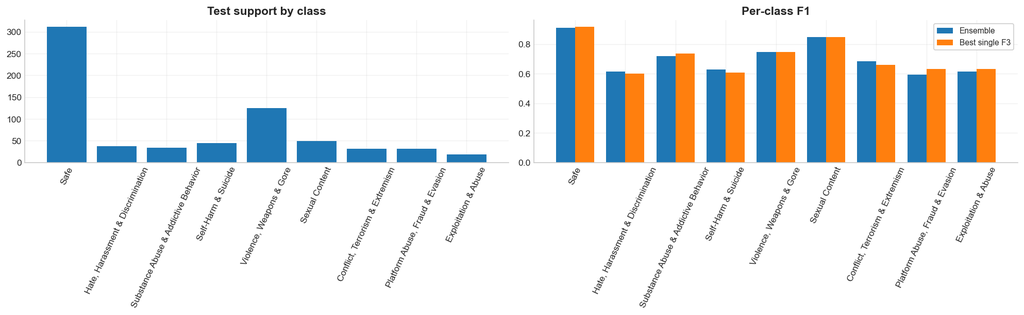

**Graph note**

These plots connect per-class support with actual test performance and compare the ensemble against the strongest single finalist.

How to read it: The support bars show which classes are scarce; the F1 bars show whether those same classes remain difficult. Gaps between the ensemble and the strongest single finalist reveal where ensembling helps or does not help by class.

This is one of the clearest places to see which unsafe subclasses remain dominant failure modes.

**Unsafe subclasses most often collapsed into Safe**

|  | class_id | class_name | support | predicted_safe_count | unsafe_to_safe_rate |
| --- | --- | --- | --- | --- | --- |
| 0 | 1 | Hate, Harassment & Discrimination | 38 | 6 | 0.157895 |
| 1 | 7 | Platform Abuse, Fraud & Evasion | 31 | 4 | 0.129032 |
| 2 | 8 | Exploitation & Abuse | 19 | 2 | 0.105263 |
| 3 | 6 | Conflict, Terrorism & Extremism | 31 | 2 | 0.064516 |
| 4 | 5 | Sexual Content | 49 | 2 | 0.040816 |
| 5 | 2 | Substance Abuse & Addictive Behavior | 34 | 1 | 0.029412 |
| 6 | 4 | Violence, Weapons & Gore | 125 | 3 | 0.024000 |
| 7 | 3 | Self-Harm & Suicide | 45 | 1 | 0.022222 |

**Largest unsafe-to-unsafe confusion channels**

|  | true_class | pred_class | count | rate_within_true |
| --- | --- | --- | --- | --- |
| 0 | Violence, Weapons & Gore | Self-Harm & Suicide | 14 | 0.112000 |
| 1 | Violence, Weapons & Gore | Conflict, Terrorism & Extremism | 10 | 0.080000 |
| 2 | Self-Harm & Suicide | Violence, Weapons & Gore | 6 | 0.133333 |
| 3 | Substance Abuse & Addictive Behavior | Self-Harm & Suicide | 5 | 0.147059 |
| 4 | Violence, Weapons & Gore | Sexual Content | 5 | 0.040000 |
| 5 | Hate, Harassment & Discrimination | Exploitation & Abuse | 3 | 0.078947 |
| 6 | Self-Harm & Suicide | Substance Abuse & Addictive Behavior | 3 | 0.066667 |
| 7 | Violence, Weapons & Gore | Hate, Harassment & Discrimination | 3 | 0.024000 |
| 8 | Exploitation & Abuse | Platform Abuse, Fraud & Evasion | 2 | 0.105263 |
| 9 | Conflict, Terrorism & Extremism | Violence, Weapons & Gore | 2 | 0.064516 |

**High-confidence ensemble errors**

|  | id | target_name | best_single_pred_name | ensemble_pred_name | combined_category | reduced_unsafe_class | best_single_conf | ensemble_conf | ensemble_p_unsafe |
| --- | --- | --- | --- | --- | --- | --- | --- | --- | --- |
| 0 | 1735 | Hate, Harassment & Discrimination | Self-Harm & Suicide | Self-Harm & Suicide | C1: Slurs, Hate Speech, Hate Symbols | Hate, Harassment & Discrimination | 0.992295 | 0.990645 | 0.999843 |
| 1 | 4239 | Hate, Harassment & Discrimination | Platform Abuse, Fraud & Evasion | Platform Abuse, Fraud & Evasion | C1: Slurs, Hate Speech, Hate Symbols | Hate, Harassment & Discrimination | 0.982075 | 0.983117 | 0.999330 |
| 2 | 986 | Violence, Weapons & Gore | Hate, Harassment & Discrimination | Hate, Harassment & Discrimination | C9: Interpersonal Violence | Violence, Weapons & Gore | 0.975211 | 0.981044 | 0.998875 |
| 3 | 5296 | Safe | Platform Abuse, Fraud & Evasion | Platform Abuse, Fraud & Evasion | NaN | NaN | 0.983307 | 0.973877 | 0.982718 |
| 4 | 6975 | Safe | Platform Abuse, Fraud & Evasion | Platform Abuse, Fraud & Evasion | NaN | NaN | 0.980557 | 0.973545 | 0.998177 |

**Low-confidence ensemble errors**

|  | id | target_name | best_single_pred_name | ensemble_pred_name | combined_category | reduced_unsafe_class | best_single_conf | ensemble_conf | ensemble_p_unsafe |
| --- | --- | --- | --- | --- | --- | --- | --- | --- | --- |
| 0 | 1262 | Conflict, Terrorism & Extremism | Substance Abuse & Addictive Behavior | Safe | C12: Terrorism and Violent Extremism | Conflict, Terrorism & Extremism | 0.178512 | 0.178885 | 0.821115 |
| 1 | 694 | Platform Abuse, Fraud & Evasion | Platform Abuse, Fraud & Evasion | Violence, Weapons & Gore | C14: Inauthentic Practices/Fraud | Platform Abuse, Fraud & Evasion | 0.273583 | 0.260588 | 0.994076 |
| 2 | 5317 | Exploitation & Abuse | Platform Abuse, Fraud & Evasion | Platform Abuse, Fraud & Evasion | C15: Human Exploitation | Exploitation & Abuse | 0.269639 | 0.267890 | 0.993481 |
| 3 | 7556 | Self-Harm & Suicide | Violence, Weapons & Gore | Violence, Weapons & Gore | C4: Self-Harm and Suicide | Self-Harm & Suicide | 0.311701 | 0.282399 | 0.997999 |
| 4 | 1720 | Platform Abuse, Fraud & Evasion | Substance Abuse & Addictive Behavior | Substance Abuse & Addictive Behavior | C14: Inauthentic Practices/Fraud | Platform Abuse, Fraud & Evasion | 0.262906 | 0.288461 | 0.977744 |

**Safety-critical unsafe -> Safe misses**

|  | id | target_name | best_single_pred_name | ensemble_pred_name | combined_category | reduced_unsafe_class | best_single_conf | ensemble_conf | ensemble_p_unsafe |
| --- | --- | --- | --- | --- | --- | --- | --- | --- | --- |
| 0 | 5446 | Platform Abuse, Fraud & Evasion | Safe | Safe | C14: Inauthentic Practices/Fraud | Platform Abuse, Fraud & Evasion | 0.962865 | 0.970869 | 0.029131 |
| 1 | 6290 | Hate, Harassment & Discrimination | Safe | Safe | C2: Discrimination and Unequal Treatment | Hate, Harassment & Discrimination | 0.898016 | 0.911043 | 0.088957 |
| 2 | 750 | Hate, Harassment & Discrimination | Safe | Safe | C1: Slurs, Hate Speech, Hate Symbols | Hate, Harassment & Discrimination | 0.857044 | 0.884249 | 0.115751 |
| 3 | 1571 | Self-Harm & Suicide | Safe | Safe | C4: Self-Harm and Suicide | Self-Harm & Suicide | 0.797129 | 0.859912 | 0.140088 |
| 4 | 2961 | Hate, Harassment & Discrimination | Safe | Safe | C1: Slurs, Hate Speech, Hate Symbols | Hate, Harassment & Discrimination | 0.810880 | 0.823114 | 0.176886 |

**Finalist-differentiating cases for F1 vs F3**

|  | id | target_name | combined_category | reduced_unsafe_class | f1_pred_name | f3_pred_name | f1_conf | f3_conf |
| --- | --- | --- | --- | --- | --- | --- | --- | --- |
| 0 | 4256 | Violence, Weapons & Gore | C5: Animal Violence and Gore | Violence, Weapons & Gore | Violence, Weapons & Gore | Conflict, Terrorism & Extremism | 0.640217 | 0.489226 |
| 1 | 1816 | Violence, Weapons & Gore | C10: Weapons and Dangerous Objects | Violence, Weapons & Gore | Violence, Weapons & Gore | Conflict, Terrorism & Extremism | 0.472915 | 0.558029 |
| 2 | 2337 | Platform Abuse, Fraud & Evasion | C13: Jailbreaks | Platform Abuse, Fraud & Evasion | Safe | Platform Abuse, Fraud & Evasion | 0.491126 | 0.568683 |
| 3 | 6725 | Safe | NaN | NaN | Hate, Harassment & Discrimination | Safe | 0.456059 | 0.379021 |
| 4 | 4520 | Platform Abuse, Fraud & Evasion | C14: Inauthentic Practices/Fraud | Platform Abuse, Fraud & Evasion | Hate, Harassment & Discrimination | Platform Abuse, Fraud & Evasion | 0.344613 | 0.393083 |

```
    **Finding.** The dominant unresolved failure mode is not just generic error; it is concentrated in specific unsafe subclasses and especially in their leakage into `Safe`.
    In this artifact set, the most severe unsafe-to-safe collapse rate is for `Hate, Harassment & Discrimination`. The case tables also show that some errors are high-confidence and therefore more operationally concerning,
    while others are low-confidence boundary cases that are better handled by thresholding or human review.
```

```python
best_single_probs = finalist_prob_map_test[best_single_rank]
best_single_metrics = metric_dict_from_probs(best_single_probs, ensemble_targets_test)

class_perf_df = pd.DataFrame(
    {
        "class_id": list(range(len(class_labels))),
        "class_name": class_labels,
        "support": ensemble_metrics["per_class_support"],
        "ensemble_f1": ensemble_metrics["per_class_f1"],
        "best_single_f1": best_single_metrics["per_class_f1"],
    }
)
display(class_perf_df)

fig, axes = plt.subplots(1, 2, figsize=(16, 5))
axes[0].bar(class_perf_df["class_name"], class_perf_df["support"])
axes[0].set_title("Test support by class")
axes[0].tick_params(axis="x", rotation=65)
width = 0.38
xs = np.arange(len(class_perf_df))
axes[1].bar(xs - width / 2, class_perf_df["ensemble_f1"], width=width, label="Ensemble")
axes[1].bar(xs + width / 2, class_perf_df["best_single_f1"], width=width, label=f"Best single F{best_single_rank}")
axes[1].set_xticks(xs, labels=class_perf_df["class_name"], rotation=65)
axes[1].set_title("Per-class F1")
axes[1].legend()
fig.tight_layout()
plt.show()
plt.close(fig)
display_note(
    title="Graph note",
    purpose="These plots connect per-class support with actual test performance and compare the ensemble against the strongest single finalist.",
    how_to_read="The support bars show which classes are scarce; the F1 bars show whether those same classes remain difficult. Gaps between the ensemble and the strongest single finalist reveal where ensembling helps or does not help by class.",
    caveat="This is one of the clearest places to see which unsafe subclasses remain dominant failure modes."
)

conf_mat = np.asarray(ensemble_metrics["confusion_matrix"], dtype=int)
unsafe_safe_rows = []
for class_id in range(1, len(class_labels)):
    support = int(conf_mat[class_id].sum())
    unsafe_safe_rows.append(
        {
            "class_id": class_id,
            "class_name": class_labels[class_id],
            "support": support,
            "predicted_safe_count": int(conf_mat[class_id, 0]),
            "unsafe_to_safe_rate": conf_mat[class_id, 0] / max(support, 1),
        }
    )
unsafe_safe_df = pd.DataFrame(unsafe_safe_rows).sort_values("unsafe_to_safe_rate", ascending=False).reset_index(drop=True)
display(Markdown("**Unsafe subclasses most often collapsed into Safe**"))
display(unsafe_safe_df)

confusion_rows = []
for true_id in range(1, len(class_labels)):
    for pred_id in range(1, len(class_labels)):
        if true_id == pred_id:
            continue
        count = int(conf_mat[true_id, pred_id])
        if count > 0:
            confusion_rows.append(
                {
                    "true_class": class_labels[true_id],
                    "pred_class": class_labels[pred_id],
                    "count": count,
                    "rate_within_true": count / max(int(conf_mat[true_id].sum()), 1),
                }
            )
top_confusions_df = pd.DataFrame(confusion_rows).sort_values(["count", "rate_within_true"], ascending=[False, False]).head(10).reset_index(drop=True)
display(Markdown("**Largest unsafe-to-unsafe confusion channels**"))
display(top_confusions_df)

error_view = base_meta.copy()
error_view["ensemble_correct"] = error_view["ensemble_pred"] == error_view["target"]
error_view["best_single_correct"] = error_view["best_single_pred"] == error_view["target"]

high_conf_errors_df = select_examples(
    error_view[~error_view["ensemble_correct"]].copy(),
    score_col="ensemble_conf",
    ascending=False,
    n_rows=5,
)[["id", "target_name", "best_single_pred_name", "ensemble_pred_name", "combined_category", "reduced_unsafe_class", "best_single_conf", "ensemble_conf", "ensemble_p_unsafe"]]

low_conf_errors_df = select_examples(
    error_view[~error_view["ensemble_correct"]].copy(),
    score_col="ensemble_conf",
    ascending=True,
    n_rows=5,
)[["id", "target_name", "best_single_pred_name", "ensemble_pred_name", "combined_category", "reduced_unsafe_class", "best_single_conf", "ensemble_conf", "ensemble_p_unsafe"]]

safety_critical_examples_df = select_examples(
    error_view[(error_view["target"] != 0) & (error_view["ensemble_pred"] == 0)].copy(),
    score_col="ensemble_conf",
    ascending=False,
    n_rows=5,
)[["id", "target_name", "best_single_pred_name", "ensemble_pred_name", "combined_category", "reduced_unsafe_class", "best_single_conf", "ensemble_conf", "ensemble_p_unsafe"]]

most_diverse_pair = overlap_df.sort_values("pred_disagreement_rate", ascending=False).iloc[0]
a_rank = int(most_diverse_pair["a"])
b_rank = int(most_diverse_pair["b"])
diff_cases_df = select_examples(
    error_view[
        (error_view[f"f{a_rank}_pred"] != error_view[f"f{b_rank}_pred"])
        & ((error_view[f"f{a_rank}_pred"] == error_view["target"]) != (error_view[f"f{b_rank}_pred"] == error_view["target"]))
    ].assign(conf_gap=lambda df_: (df_[f"f{a_rank}_conf"] - df_[f"f{b_rank}_conf"]).abs()),
    score_col="conf_gap",
    ascending=False,
    n_rows=5,
).assign(
    **{
        f"f{a_rank}_pred_name": lambda df_: df_[f"f{a_rank}_pred"].map(dict(enumerate(class_labels))),
        f"f{b_rank}_pred_name": lambda df_: df_[f"f{b_rank}_pred"].map(dict(enumerate(class_labels))),
    }
)[["id", "target_name", "combined_category", "reduced_unsafe_class", f"f{a_rank}_pred_name", f"f{b_rank}_pred_name", f"f{a_rank}_conf", f"f{b_rank}_conf"]]

display(Markdown("**High-confidence ensemble errors**"))
display(high_conf_errors_df)
display(Markdown("**Low-confidence ensemble errors**"))
display(low_conf_errors_df)
display(Markdown("**Safety-critical unsafe -> Safe misses**"))
display(safety_critical_examples_df)
display(Markdown(f"**Finalist-differentiating cases for F{a_rank} vs F{b_rank}**"))
display(diff_cases_df)

dominant_failure = unsafe_safe_df.iloc[0]["class_name"]
display(
    Markdown(
        f'''
        **Finding.** The dominant unresolved failure mode is not just generic error; it is concentrated in specific unsafe subclasses and especially in their leakage into `Safe`.
        In this artifact set, the most severe unsafe-to-safe collapse rate is for `{dominant_failure}`. The case tables also show that some errors are high-confidence and therefore more operationally concerning,
        while others are low-confidence boundary cases that are better handled by thresholding or human review.
        '''
    )
)
```

### Example-Based Interpretability Audit

The extra audit also built query-level nearest-neighbor casebooks. Those are useful because they explain *why* a prediction looks plausible or implausible in terms of nearby training examples, which is often more interpretable for this frozen-CLIP-plus-fusion setup than pixel saliency alone.

**Representative interpretability queries selected by the extra audit**

|  | id | target_name | ensemble_pred_name | ensemble_conf | ensemble_p_unsafe | ensemble_correct | n_unique_finalist_preds |
| --- | --- | --- | --- | --- | --- | --- | --- |
| 0 | 8076 | Substance Abuse & Addictive Behavior | Self-Harm & Suicide | 0.492961 | 0.999676 | 0 | 2 |
| 1 | 7893 | Violence, Weapons & Gore | Substance Abuse & Addictive Behavior | 0.492277 | 0.998382 | 0 | 2 |
| 2 | 4078 | Platform Abuse, Fraud & Evasion | Safe | 0.486250 | 0.513750 | 0 | 2 |
| 3 | 5215 | Violence, Weapons & Gore | Conflict, Terrorism & Extremism | 0.477433 | 0.997870 | 0 | 2 |
| 4 | 4256 | Violence, Weapons & Gore | Violence, Weapons & Gore | 0.597971 | 0.999763 | 1 | 2 |
| 5 | 7490 | Violence, Weapons & Gore | Violence, Weapons & Gore | 0.533301 | 0.999260 | 1 | 2 |
| 6 | 6217 | Self-Harm & Suicide | Self-Harm & Suicide | 0.463602 | 0.998834 | 1 | 2 |
| 7 | 1816 | Violence, Weapons & Gore | Violence, Weapons & Gore | 0.437413 | 0.992321 | 1 | 2 |

**Nearest-neighbor summary from the saved casebook table**

|  | model | space | query_count | top5_same_target_rate | mean_neighbor_distance |
| --- | --- | --- | --- | --- | --- |
| 0 | F1 | learned | 16 | 0.2375 | 0.027355 |
| 1 | F1 | raw | 16 | 0.3375 | 0.381800 |
| 2 | F2 | learned | 16 | 0.2375 | 0.027353 |
| 3 | F2 | raw | 16 | 0.3375 | 0.381800 |
| 4 | F3 | learned | 16 | 0.2500 | 0.022749 |
| 5 | F3 | raw | 16 | 0.3375 | 0.381800 |
| 6 | F4 | learned | 16 | 0.2500 | 0.026817 |
| 7 | F4 | raw | 16 | 0.3375 | 0.381800 |

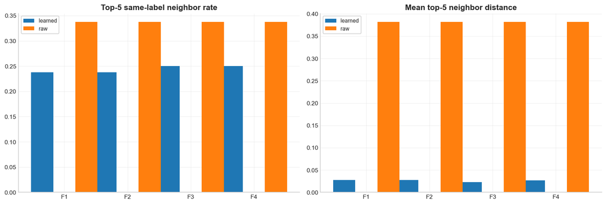

**Graph note**

These bars summarize the extra-audit nearest-neighbor casebook for the selected interpretability queries.

How to read it: Higher same-label rate means neighbors are semantically more aligned with the query's true class. Lower mean distance means the local neighborhood is tighter, although tight neighborhoods are only reassuring when they also preserve the right label.

This is still a casebook-driven interpretability diagnostic; it helps explain local behavior, but it does not replace the global representation metrics in the next section.

**Selected nearest-neighbor evidence for two high-value queries**

|  | query_id | model | space | neighbor_rank | distance | neighbor_target_name | same_target_name | neighbor_category |
| --- | --- | --- | --- | --- | --- | --- | --- | --- |
| 0 | 7893 | F1 | learned | 1 | 0.043184 | Violence, Weapons & Gore | True | C10: Weapons and Dangerous Objects |
| 1 | 7893 | F1 | learned | 2 | 0.045092 | Violence, Weapons & Gore | True | C10: Weapons and Dangerous Objects |
| 2 | 7893 | F1 | learned | 3 | 0.045267 | Violence, Weapons & Gore | True | C10: Weapons and Dangerous Objects |
| 3 | 7893 | F1 | raw | 1 | 0.463094 | Violence, Weapons & Gore | True | C11: Gore and Graphic Content |
| 4 | 7893 | F1 | raw | 2 | 0.487747 | Hate, Harassment & Discrimination | False | C1: Slurs, Hate Speech, Hate Symbols |
| 5 | 7893 | F1 | raw | 3 | 0.488333 | Violence, Weapons & Gore | True | C10: Weapons and Dangerous Objects |
| 6 | 7893 | F2 | learned | 1 | 0.043178 | Violence, Weapons & Gore | True | C10: Weapons and Dangerous Objects |
| 7 | 7893 | F2 | learned | 2 | 0.045100 | Violence, Weapons & Gore | True | C10: Weapons and Dangerous Objects |
| 8 | 7893 | F2 | learned | 3 | 0.045277 | Violence, Weapons & Gore | True | C10: Weapons and Dangerous Objects |
| 9 | 7893 | F2 | raw | 1 | 0.463094 | Violence, Weapons & Gore | True | C11: Gore and Graphic Content |
| 10 | 7893 | F2 | raw | 2 | 0.487747 | Hate, Harassment & Discrimination | False | C1: Slurs, Hate Speech, Hate Symbols |
| 11 | 7893 | F2 | raw | 3 | 0.488333 | Violence, Weapons & Gore | True | C10: Weapons and Dangerous Objects |
| 12 | 7893 | F3 | learned | 1 | 0.032812 | Violence, Weapons & Gore | True | C10: Weapons and Dangerous Objects |
| 13 | 7893 | F3 | learned | 2 | 0.036676 | Violence, Weapons & Gore | True | C10: Weapons and Dangerous Objects |
| 14 | 7893 | F3 | learned | 3 | 0.038452 | Violence, Weapons & Gore | True | C10: Weapons and Dangerous Objects |
| 15 | 7893 | F3 | raw | 1 | 0.463094 | Violence, Weapons & Gore | True | C11: Gore and Graphic Content |
| 16 | 7893 | F3 | raw | 2 | 0.487747 | Hate, Harassment & Discrimination | False | C1: Slurs, Hate Speech, Hate Symbols |
| 17 | 7893 | F3 | raw | 3 | 0.488333 | Violence, Weapons & Gore | True | C10: Weapons and Dangerous Objects |
| 18 | 7893 | F4 | learned | 1 | 0.039221 | Violence, Weapons & Gore | True | C10: Weapons and Dangerous Objects |
| 19 | 7893 | F4 | learned | 2 | 0.040606 | Violence, Weapons & Gore | True | C10: Weapons and Dangerous Objects |
| 20 | 7893 | F4 | learned | 3 | 0.040759 | Violence, Weapons & Gore | True | C10: Weapons and Dangerous Objects |
| 21 | 7893 | F4 | raw | 1 | 0.463094 | Violence, Weapons & Gore | True | C11: Gore and Graphic Content |
| 22 | 7893 | F4 | raw | 2 | 0.487747 | Hate, Harassment & Discrimination | False | C1: Slurs, Hate Speech, Hate Symbols |
| 23 | 7893 | F4 | raw | 3 | 0.488333 | Violence, Weapons & Gore | True | C10: Weapons and Dangerous Objects |
| 24 | 8076 | F1 | learned | 1 | 0.019222 | Self-Harm & Suicide | False | C4: Self-Harm and Suicide |
| 25 | 8076 | F1 | learned | 2 | 0.021376 | Self-Harm & Suicide | False | C4: Self-Harm and Suicide |
| 26 | 8076 | F1 | learned | 3 | 0.022548 | Self-Harm & Suicide | False | C4: Self-Harm and Suicide |
| 27 | 8076 | F1 | raw | 1 | 0.199472 | Substance Abuse & Addictive Behavior | True | C3: Drug Abuse |
| 28 | 8076 | F1 | raw | 2 | 0.263275 | Substance Abuse & Addictive Behavior | True | C3: Drug Abuse |
| 29 | 8076 | F1 | raw | 3 | 0.279798 | Self-Harm & Suicide | False | C4: Self-Harm and Suicide |
| 30 | 8076 | F2 | learned | 1 | 0.019203 | Self-Harm & Suicide | False | C4: Self-Harm and Suicide |
| 31 | 8076 | F2 | learned | 2 | 0.021360 | Self-Harm & Suicide | False | C4: Self-Harm and Suicide |
| 32 | 8076 | F2 | learned | 3 | 0.022547 | Self-Harm & Suicide | False | C4: Self-Harm and Suicide |
| 33 | 8076 | F2 | raw | 1 | 0.199472 | Substance Abuse & Addictive Behavior | True | C3: Drug Abuse |
| 34 | 8076 | F2 | raw | 2 | 0.263275 | Substance Abuse & Addictive Behavior | True | C3: Drug Abuse |
| 35 | 8076 | F2 | raw | 3 | 0.279798 | Self-Harm & Suicide | False | C4: Self-Harm and Suicide |
| 36 | 8076 | F3 | learned | 1 | 0.015258 | Self-Harm & Suicide | False | C4: Self-Harm and Suicide |
| 37 | 8076 | F3 | learned | 2 | 0.018085 | Violence, Weapons & Gore | False | C9: Interpersonal Violence |
| 38 | 8076 | F3 | learned | 3 | 0.018589 | Self-Harm & Suicide | False | C4: Self-Harm and Suicide |
| 39 | 8076 | F3 | raw | 1 | 0.199472 | Substance Abuse & Addictive Behavior | True | C3: Drug Abuse |
| 40 | 8076 | F3 | raw | 2 | 0.263275 | Substance Abuse & Addictive Behavior | True | C3: Drug Abuse |
| 41 | 8076 | F3 | raw | 3 | 0.279798 | Self-Harm & Suicide | False | C4: Self-Harm and Suicide |
| 42 | 8076 | F4 | learned | 1 | 0.018175 | Self-Harm & Suicide | False | C4: Self-Harm and Suicide |
| 43 | 8076 | F4 | learned | 2 | 0.020822 | Self-Harm & Suicide | False | C4: Self-Harm and Suicide |
| 44 | 8076 | F4 | learned | 3 | 0.021590 | Self-Harm & Suicide | False | C4: Self-Harm and Suicide |
| 45 | 8076 | F4 | raw | 1 | 0.199472 | Substance Abuse & Addictive Behavior | True | C3: Drug Abuse |
| 46 | 8076 | F4 | raw | 2 | 0.263275 | Substance Abuse & Addictive Behavior | True | C3: Drug Abuse |
| 47 | 8076 | F4 | raw | 3 | 0.279798 | Self-Harm & Suicide | False | C4: Self-Harm and Suicide |

*Full HTML casebook saved at `output/clip/analysis/cv3/cv_beam_v3/finalist_extra_audit/casebooks/knn_casebook.html` for image-level browsing outside the notebook.*

[output not shown]

```python
query_summary_df = audit_queries_df[[
    "id",
    "target_name",
    "ensemble_pred_name",
    "ensemble_conf",
    "ensemble_p_unsafe",
    "ensemble_correct",
    "n_unique_finalist_preds",
]].copy()
query_summary_df = query_summary_df.sort_values(
    ["n_unique_finalist_preds", "ensemble_correct", "ensemble_conf"],
    ascending=[False, True, False],
).reset_index(drop=True)
display(Markdown("**Representative interpretability queries selected by the extra audit**"))
display(query_summary_df.head(8))

knn_join_df = audit_knn_df.merge(
    audit_queries_df[["id", "target_name", "target_binary"]].rename(columns={"id": "query_id"}),
    on="query_id",
    how="left",
)
knn_join_df["same_target_name"] = knn_join_df["neighbor_target_name"] == knn_join_df["target_name"]
knn_summary_df = (
    knn_join_df[knn_join_df["neighbor_rank"] <= 5]
    .groupby(["model", "space"])
    .agg(
        query_count=("query_id", "nunique"),
        top5_same_target_rate=("same_target_name", "mean"),
        mean_neighbor_distance=("distance", "mean"),
    )
    .reset_index()
    .sort_values(["model", "space"])
)
display(Markdown("**Nearest-neighbor summary from the saved casebook table**"))
display(knn_summary_df)

fig, axes = plt.subplots(1, 2, figsize=(14, 4.8))
knn_plot_df = knn_summary_df.copy()
knn_models = knn_plot_df["model"].drop_duplicates().tolist()
knn_spaces = knn_plot_df["space"].drop_duplicates().tolist()
xs = np.arange(len(knn_models))
width = 0.35 if len(knn_spaces) <= 2 else 0.22
offsets = np.linspace(-width, width, len(knn_spaces)) if len(knn_spaces) > 1 else np.array([0.0])
for idx, space in enumerate(knn_spaces):
    sub = knn_plot_df[knn_plot_df["space"] == space].set_index("model").reindex(knn_models)
    axes[0].bar(xs + offsets[idx], sub["top5_same_target_rate"], width=width, label=space)
    axes[1].bar(xs + offsets[idx], sub["mean_neighbor_distance"], width=width, label=space)
axes[0].set_title("Top-5 same-label neighbor rate")
axes[1].set_title("Mean top-5 neighbor distance")
for ax in axes:
    ax.set_xticks(xs, labels=knn_models)
    ax.legend()
fig.tight_layout()
plt.show()
plt.close(fig)
display_note(
    title="Graph note",
    purpose="These bars summarize the extra-audit nearest-neighbor casebook for the selected interpretability queries.",
    how_to_read="Higher same-label rate means neighbors are semantically more aligned with the query's true class. Lower mean distance means the local neighborhood is tighter, although tight neighborhoods are only reassuring when they also preserve the right label.",
    caveat="This is still a casebook-driven interpretability diagnostic; it helps explain local behavior, but it does not replace the global representation metrics in the next section."
)

showcase_query_ids = query_summary_df.head(2)["id"].tolist()
showcase_neighbors_df = (
    knn_join_df[(knn_join_df["query_id"].isin(showcase_query_ids)) & (knn_join_df["neighbor_rank"] <= 3)]
    .sort_values(["query_id", "model", "space", "neighbor_rank"])
    .reset_index(drop=True)
)
display(Markdown("**Selected nearest-neighbor evidence for two high-value queries**"))
display(showcase_neighbors_df[[
    "query_id",
    "model",
    "space",
    "neighbor_rank",
    "distance",
    "neighbor_target_name",
    "same_target_name",
    "neighbor_category",
]])
display(
    Markdown(
        f"_Full HTML casebook saved at `{(EXTRA_AUDIT_ROOT / 'casebooks' / 'knn_casebook.html').as_posix()}` for image-level browsing outside the notebook._"
    )
)

knn_gain_rows = []
if "raw" in knn_spaces and "learned" in knn_spaces:
    for model in knn_models:
        model_sub = knn_summary_df[knn_summary_df["model"] == model].set_index("space")
        if {"raw", "learned"}.issubset(model_sub.index):
            knn_gain_rows.append(
                {
                    "model": model,
                    "top5_same_target_gain": float(model_sub.loc["learned", "top5_same_target_rate"] - model_sub.loc["raw", "top5_same_target_rate"]),
                    "distance_change": float(model_sub.loc["learned", "mean_neighbor_distance"] - model_sub.loc["raw", "mean_neighbor_distance"]),
                }
            )
knn_gain_df = pd.DataFrame(knn_gain_rows)
best_knn_gain_row = knn_gain_df.sort_values("top5_same_target_gain", ascending=False).iloc[0] if not knn_gain_df.empty else None
gain_text = (
    f"The biggest same-label gain is for `{best_knn_gain_row['model']}` at {best_knn_gain_row['top5_same_target_gain']:+.4f}."
    if best_knn_gain_row is not None
    else "The saved casebook does not include a raw-vs-learned pair for every model, so the query-level gain is summarized qualitatively."
)
display(
    Markdown(
        f'''
        **Finding.** The interpretability casebook is most useful when it explains *local* behavior: which kinds of examples each finalist considers similar,
        and whether the learned neighborhood looks more class-faithful than the raw CLIP neighborhood. The top-5 same-label table above shows that pattern directly. {gain_text}
        That makes the casebook a concrete complement to the more global representation metrics below.
        '''
    )
)
```

### Meaningful-Learning Audit

Two-dimensional plots can be suggestive, but they should not carry the whole claim. This section compares frozen CLIP features with learned fused/trunk representations using quantitative structure checks first, then uses PCA and t-SNE only as supporting visuals. The quantitative comparison is repeated across more than one finalist run; the 2D plots below are shown only for one representative probe so the notebook stays readable.

```
    **Probe choice note.** This representation audit uses `F3, F1` as probes because `F3` is the strongest macro-F1 representative,
    and `F1` provides the most safety-distinct / disagreement-relevant companion view from the shortlisted finalists.
    The omitted finalists (`F2, F4`) are not shown here because the overlap and finalist diagnostics already suggest they are near-duplicates of one shown probe or not materially more informative for this representation-specific diagnostic.
```

**All-finalist representation summary from the extra audit**

|  | model | repr_space | view_label | n_samples | knn_purity_at_10 | centroid_separation_ratio | silhouette_like |
| --- | --- | --- | --- | --- | --- | --- | --- |
| 0 | F1 | Frozen_CLIP | All classes | 505 | 0.491089 | 0.441416 | 0.010065 |
| 1 | F1 | Learned_trunk | All classes | 505 | 0.650495 | 1.333265 | 0.113450 |
| 2 | F1 | Frozen_CLIP | Unsafe only | 359 | 0.435097 | 0.440238 | 0.004679 |
| 3 | F1 | Learned_trunk | Unsafe only | 359 | 0.608635 | 1.308315 | 0.081493 |
| 4 | F2 | Frozen_CLIP | All classes | 505 | 0.482376 | 0.438813 | 0.008467 |
| 5 | F2 | Learned_trunk | All classes | 505 | 0.652673 | 1.336906 | 0.116161 |
| 6 | F2 | Frozen_CLIP | Unsafe only | 359 | 0.433148 | 0.440092 | 0.004700 |
| 7 | F2 | Learned_trunk | Unsafe only | 359 | 0.610864 | 1.305592 | 0.080230 |
| 8 | F3 | Frozen_CLIP | All classes | 505 | 0.484158 | 0.437670 | 0.007951 |
| 9 | F3 | Learned_trunk | All classes | 505 | 0.665545 | 1.371467 | 0.120209 |
| 10 | F3 | Frozen_CLIP | Unsafe only | 359 | 0.435376 | 0.440355 | 0.004760 |
| 11 | F3 | Learned_trunk | Unsafe only | 359 | 0.622006 | 1.335975 | 0.083122 |
| 12 | F4 | Frozen_CLIP | All classes | 505 | 0.491485 | 0.439360 | 0.008992 |
| 13 | F4 | Learned_trunk | All classes | 505 | 0.645545 | 1.334299 | 0.106745 |
| 14 | F4 | Frozen_CLIP | Unsafe only | 359 | 0.435655 | 0.439622 | 0.004247 |
| 15 | F4 | Learned_trunk | Unsafe only | 359 | 0.620891 | 1.324074 | 0.084579 |

**All-finalist gains from frozen CLIP to learned trunk space**

|  | model | view_label | knn_gain | separation_gain |
| --- | --- | --- | --- | --- |
| 0 | F1 | All classes | 0.159406 | 0.891849 |
| 1 | F1 | Unsafe only | 0.173538 | 0.868077 |
| 2 | F2 | All classes | 0.170297 | 0.898093 |
| 3 | F2 | Unsafe only | 0.177716 | 0.865499 |
| 4 | F3 | All classes | 0.181386 | 0.933797 |
| 5 | F3 | Unsafe only | 0.186630 | 0.895620 |
| 6 | F4 | All classes | 0.154059 | 0.894938 |
| 7 | F4 | Unsafe only | 0.185237 | 0.884452 |

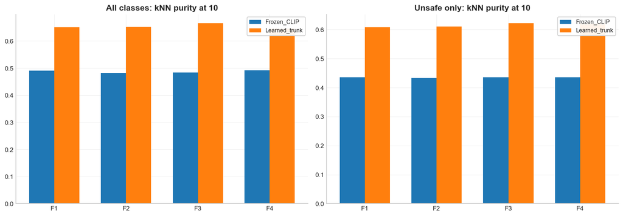

**Graph note**

These bars summarize the saved extra-audit representation metrics across all finalists before the notebook zooms into a smaller set of probe runs.

How to read it: Higher learned-trunk bars than frozen-CLIP bars mean the trained representation creates purer local neighborhoods, which is one concrete sign that the model learned structure beyond the frozen baseline.

This all-finalist summary is intentionally broad; the probe-level PCA and t-SNE views below are narrower but more visually detailed.

**All 9 classes: structure metrics**

|  | probe_finalist | space | n_samples | knn_purity_at_10 | centroid_separation_ratio | silhouette_like |
| --- | --- | --- | --- | --- | --- | --- |
| 0 | F3 | Frozen_CLIP_concat | 505 | 0.486931 | 0.439793 | 0.008978 |
| 1 | F3 | Learned_fused | 505 | 0.645545 | 1.395877 | 0.116278 |
| 2 | F3 | Learned_trunk | 505 | 0.642772 | 1.399550 | 0.118160 |
| 3 | F1 | Frozen_CLIP_concat | 505 | 0.492673 | 0.439813 | 0.008838 |
| 4 | F1 | Learned_fused | 505 | 0.642376 | 1.361861 | 0.114308 |
| 5 | F1 | Learned_trunk | 505 | 0.651089 | 1.366470 | 0.119815 |

**Unsafe subclasses only: structure metrics**

|  | probe_finalist | space | n_samples | knn_purity_at_10 | centroid_separation_ratio | silhouette_like |
| --- | --- | --- | --- | --- | --- | --- |
| 0 | F3 | Frozen_CLIP_concat | 359 | 0.436212 | 0.441193 | 0.004921 |
| 1 | F3 | Learned_fused | 359 | 0.608914 | 1.367015 | 0.082260 |
| 2 | F3 | Learned_trunk | 359 | 0.611142 | 1.368473 | 0.082904 |
| 3 | F1 | Frozen_CLIP_concat | 359 | 0.445682 | 0.441456 | 0.005162 |
| 4 | F1 | Learned_fused | 359 | 0.611421 | 1.334155 | 0.081703 |
| 5 | F1 | Learned_trunk | 359 | 0.613370 | 1.332949 | 0.081368 |

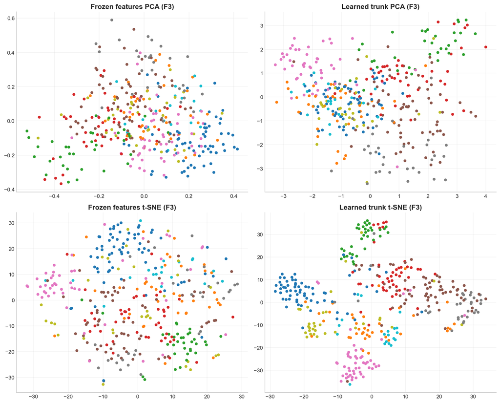

**Graph note**

These PCA and t-SNE plots are visual diagnostics for how the learned representation compares with the frozen CLIP baseline on one representative probe run.

How to read it: Cleaner clustering or separation in the learned-trunk panels suggests the model has reshaped the feature space usefully. The visual should be read alongside the quantitative structure metrics above, not on its own.

These 2D projections are illustrative and sample-dependent; the structure-metric tables carry the main evidence.

**Probe-level gains from frozen CLIP space to learned trunk space**

|  | probe_finalist | knn_gain | sep_gain |
| --- | --- | --- | --- |
| 0 | F1 | 0.158416 | 0.926658 |
| 1 | F3 | 0.155842 | 0.959757 |

```
    **Finding.** The strongest claim here should come from the quantitative structure metrics, not from the 2D projections alone. The all-finalist summary above shows how much kNN purity and centroid separation improve from frozen CLIP to learned trunk space across the shortlisted models,
    and the probe-level audit then checks that the same pattern is visible in raw run features. Across the probe runs `F1, F3`,
    the learned trunk improves neighborhood purity over the frozen CLIP baseline by `F1: +0.1584, F3: +0.1558`.
    The 2D plots remain a supporting diagnostic for `F3`, while the all-finalist gain table and the probe-level structure table carry the main evidence about whether unsafe subclasses become more separable.
```

```python
strongest_rank = int(single_model_df.sort_values(["macro_f1", "unsafe_macro_f1", "missed_as_safe_rate"], ascending=[False, False, True]).iloc[0]["finalist_rank"])
safety_probe_rank = int(single_model_df.sort_values(["missed_as_safe_rate", "unsafe_macro_f1"], ascending=[True, False]).iloc[0]["finalist_rank"])
probe_ranks = [strongest_rank]
if safety_probe_rank not in probe_ranks:
    probe_ranks.append(safety_probe_rank)
else:
    diverse_rank = int(overlap_df.loc[(overlap_df["a"] == strongest_rank) | (overlap_df["b"] == strongest_rank)].assign(other=lambda df_: np.where(df_["a"] == strongest_rank, df_["b"], df_["a"])).sort_values("pred_disagreement_rate", ascending=False).iloc[0]["other"])
    if diverse_rank not in probe_ranks:
        probe_ranks.append(diverse_rank)

omitted_probe_ranks = [rank for rank in sorted(single_model_df["finalist_rank"].tolist()) if rank not in probe_ranks]
display(
    Markdown(
        f'''
        **Probe choice note.** This representation audit uses `{', '.join([f"F{rank}" for rank in probe_ranks])}` as probes because `F{strongest_rank}` is the strongest macro-F1 representative,
        and `{', '.join([f"F{rank}" for rank in probe_ranks if rank != strongest_rank])}` provides the most safety-distinct / disagreement-relevant companion view from the shortlisted finalists.
        The omitted finalists (`{', '.join([f"F{rank}" for rank in omitted_probe_ranks]) if omitted_probe_ranks else 'none'}`) are not shown here because the overlap and finalist diagnostics already suggest they are near-duplicates of one shown probe or not materially more informative for this representation-specific diagnostic.
        '''
    )
)

repr_audit_df = audit_repr_summary_df.copy()
repr_audit_df["model"] = repr_audit_df["space"].str.extract(r"^(F\d+)")[0]
repr_audit_df["repr_space"] = np.where(repr_audit_df["space"].str.endswith("_raw"), "Frozen_CLIP", "Learned_trunk")
repr_audit_df["view_label"] = repr_audit_df["view"].map({"all_classes": "All classes", "unsafe_only": "Unsafe only"}).fillna(repr_audit_df["view"])
display(Markdown("**All-finalist representation summary from the extra audit**"))
display(repr_audit_df[["model", "repr_space", "view_label", "n_samples", "knn_purity_at_10", "centroid_separation_ratio", "silhouette_like"]])

repr_gain_rows = []
for (model, view), sub in repr_audit_df.groupby(["model", "view_label"]):
    sub = sub.set_index("repr_space")
    if {"Frozen_CLIP", "Learned_trunk"}.issubset(sub.index):
        repr_gain_rows.append(
            {
                "model": model,
                "view_label": view,
                "knn_gain": float(sub.loc["Learned_trunk", "knn_purity_at_10"] - sub.loc["Frozen_CLIP", "knn_purity_at_10"]),
                "separation_gain": float(sub.loc["Learned_trunk", "centroid_separation_ratio"] - sub.loc["Frozen_CLIP", "centroid_separation_ratio"]),
            }
        )
repr_gain_df = pd.DataFrame(repr_gain_rows)
display(Markdown("**All-finalist gains from frozen CLIP to learned trunk space**"))
display(repr_gain_df)

view_order = [view for view in ["All classes", "Unsafe only"] if view in repr_audit_df["view_label"].unique().tolist()]
if view_order:
    fig, axes = plt.subplots(1, len(view_order), figsize=(6.8 * len(view_order), 4.8))
    axes = np.atleast_1d(axes)
    for ax, view in zip(axes, view_order):
        view_df = repr_audit_df[repr_audit_df["view_label"] == view]
        models = view_df["model"].drop_duplicates().tolist()
        xs = np.arange(len(models))
        width = 0.35
        for idx, repr_space in enumerate(["Frozen_CLIP", "Learned_trunk"]):
            sub = view_df[view_df["repr_space"] == repr_space].set_index("model").reindex(models)
            ax.bar(xs + (-width / 2 if idx == 0 else width / 2), sub["knn_purity_at_10"], width=width, label=repr_space)
        ax.set_title(f"{view}: kNN purity at 10")
        ax.set_xticks(xs, labels=models)
        ax.legend()
    fig.tight_layout()
    plt.show()
    plt.close(fig)
    display_note(
        title="Graph note",
        purpose="These bars summarize the saved extra-audit representation metrics across all finalists before the notebook zooms into a smaller set of probe runs.",
        how_to_read="Higher learned-trunk bars than frozen-CLIP bars mean the trained representation creates purer local neighborhoods, which is one concrete sign that the model learned structure beyond the frozen baseline.",
        caveat="This all-finalist summary is intentionally broad; the probe-level PCA and t-SNE views below are narrower but more visually detailed."
    )

structure_rows = []
unsafe_structure_rows = []
feature_cache = {}
for rank in probe_ranks:
    run_name = finalists_payload["finalists"][rank - 1]["members"][0]["run_name"]
    raw_features, fused_features, hidden_features, rep_labels_df = load_model_hidden(run_name, split_name="test")
    rep_labels = rep_labels_df["composite_9way_label"].to_numpy(dtype=int)
    feature_cache[rank] = (run_name, raw_features, fused_features, hidden_features, rep_labels)
    feature_spaces = {
        "Frozen_CLIP_concat": raw_features,
        "Learned_fused": fused_features,
        "Learned_trunk": hidden_features,
    }
    unsafe_mask = rep_labels != 0
    for name, feats in feature_spaces.items():
        global_stats = structure_metrics(feats, rep_labels, max_samples=1200)
        structure_rows.append({"probe_finalist": f"F{rank}", "space": name, **global_stats})
        if unsafe_mask.sum() >= 40:
            unsafe_stats = structure_metrics(feats[unsafe_mask], rep_labels[unsafe_mask] - 1, max_samples=900)
            unsafe_structure_rows.append({"probe_finalist": f"F{rank}", "space": name, **unsafe_stats})

structure_summary_df = pd.DataFrame(structure_rows)
unsafe_structure_summary_df = pd.DataFrame(unsafe_structure_rows)
display(Markdown("**All 9 classes: structure metrics**"))
display(structure_summary_df)
display(Markdown("**Unsafe subclasses only: structure metrics**"))
display(unsafe_structure_summary_df)

reference_rank = probe_ranks[0]
reference_run, raw_features, fused_features, hidden_features, rep_labels = feature_cache[reference_rank]
pca_raw_df, tsne_raw_df = pca_tsne_frames(raw_features, rep_labels, max_samples=600)
pca_hidden_df, tsne_hidden_df = pca_tsne_frames(hidden_features, rep_labels, max_samples=600)

fig, axes = plt.subplots(2, 2, figsize=(13, 10.5))
axes[0, 0].scatter(pca_raw_df["x"], pca_raw_df["y"], c=pca_raw_df["label"], cmap="tab10", s=18)
axes[0, 0].set_title(f"Frozen features PCA ({short_run_label(reference_run)})")
axes[0, 1].scatter(pca_hidden_df["x"], pca_hidden_df["y"], c=pca_hidden_df["label"], cmap="tab10", s=18)
axes[0, 1].set_title(f"Learned trunk PCA ({short_run_label(reference_run)})")
axes[1, 0].scatter(tsne_raw_df["x"], tsne_raw_df["y"], c=tsne_raw_df["label"], cmap="tab10", s=18)
axes[1, 0].set_title(f"Frozen features t-SNE ({short_run_label(reference_run)})")
axes[1, 1].scatter(tsne_hidden_df["x"], tsne_hidden_df["y"], c=tsne_hidden_df["label"], cmap="tab10", s=18)
axes[1, 1].set_title(f"Learned trunk t-SNE ({short_run_label(reference_run)})")
fig.tight_layout()
plt.show()
plt.close(fig)
display_note(
    title="Graph note",
    purpose="These PCA and t-SNE plots are visual diagnostics for how the learned representation compares with the frozen CLIP baseline on one representative probe run.",
    how_to_read="Cleaner clustering or separation in the learned-trunk panels suggests the model has reshaped the feature space usefully. The visual should be read alongside the quantitative structure metrics above, not on its own.",
    caveat="These 2D projections are illustrative and sample-dependent; the structure-metric tables carry the main evidence."
)

gain_rows = []
for probe in sorted(structure_summary_df["probe_finalist"].unique()):
    probe_df = structure_summary_df[structure_summary_df["probe_finalist"] == probe]
    gain_rows.append(
        {
            "probe_finalist": probe,
            "knn_gain": float(probe_df.loc[probe_df["space"] == "Learned_trunk", "knn_purity_at_10"].iloc[0] - probe_df.loc[probe_df["space"] == "Frozen_CLIP_concat", "knn_purity_at_10"].iloc[0]),
            "sep_gain": float(probe_df.loc[probe_df["space"] == "Learned_trunk", "centroid_separation_ratio"].iloc[0] - probe_df.loc[probe_df["space"] == "Frozen_CLIP_concat", "centroid_separation_ratio"].iloc[0]),
        }
    )
structure_gain_df = pd.DataFrame(gain_rows)
display(Markdown("**Probe-level gains from frozen CLIP space to learned trunk space**"))
display(structure_gain_df)

display(
    Markdown(
        f'''
        **Finding.** The strongest claim here should come from the quantitative structure metrics, not from the 2D projections alone. The all-finalist summary above shows how much kNN purity and centroid separation improve from frozen CLIP to learned trunk space across the shortlisted models,
        and the probe-level audit then checks that the same pattern is visible in raw run features. Across the probe runs `{', '.join(structure_gain_df['probe_finalist'].tolist())}`,
        the learned trunk improves neighborhood purity over the frozen CLIP baseline by `{', '.join([f"{row.probe_finalist}: {row.knn_gain:+.4f}" for row in structure_gain_df.itertuples()])}`.
        The 2D plots remain a supporting diagnostic for `{short_run_label(reference_run)}`, while the all-finalist gain table and the probe-level structure table carry the main evidence about whether unsafe subclasses become more separable.
        '''
    )
)
```